# # 词袋模型

词袋模型（Bag of Words，简称 BoW）是自然语言处理（NLP）中常用的文本表示方法，它将文本转化为数值特征（向量），进而可以用于机器学习等高阶处理。词袋模型将语料转化为二维矩阵，横向为所有在训练数据中出现的不重复的词汇（word），纵向为语料各句子或文档（document）。

简单来说，词袋模型可以帮助大家计算词频。

```python
import pandas as pd #数据表
import numpy as np #数组运算
import nltk #英文语料处理
import re #正则表达式（用于数据清洗）
import matplotlib.pyplot as plt #画图
from wordcloud import WordCloud #词云图
from nltk.stem import WordNetLemmatizer
from nltk.tokenize import TweetTokenizer
```

```python
#导入数据
text_ana=pd.read_csv('text_analysis_twitter.csv')
text_ana=text_ana.drop(['Unnamed: 0'],axis=1)#Unnamed:需要有空格
```

```python
text_ana
```

|  | id | screen_name | time | link | text | source |
| --- | --- | --- | --- | --- | --- | --- |
| 0 | 881004944714866688 | KamalaHarris | 2017-07-01T00:22:01-04:00 | https://www.twitter.com/KamalaHarris/statuses/... | Republicans are trying to steal health care fr... | Sprout Social |
| 1 | 881002538341986304 | MarcVeasey | 2017-07-01T00:12:28-04:00 | https://www.twitter.com/kylegriffin1/statuses/... | RT @kylegriffin1 Rep. Mark Veasay has introduc... | Twitter for Android |
| 2 | 881001393284419584 | RepPaulTonko | 2017-07-01T00:07:55-04:00 | https://www.twitter.com/RepPaulTonko/statuses/... | A top U.S. science office went dark tonight. N... | Twitter for iPhone |
| 3 | 881000301007958016 | clairecmc | 2017-07-01T00:03:34-04:00 | https://www.twitter.com/clairecmc/statuses/881... | So the fundraising quarter ends in an hour in ... | Twitter for iPad |
| 4 | 881015727540637696 | tedcruz | 2017-07-01T01:04:52-04:00 | https://www.twitter.com/larry_kudlow/statuses/... | RT @larry_kudlow Important story @SenTedCruz @... | Twitter for iPhone |
| ... | ... | ... | ... | ... | ... | ... |
| 299995 | 939743413909549056 | RepTedLieu | 2017-12-10T01:27:44-05:00 | https://www.twitter.com/ReadyLA/statuses/93956... | RT @ReadyLA REPORT FIRE DAMAGE from #CreekFire... | Twitter for iPhone |
| 299996 | 939743003203301376 | RepTedLieu | 2017-12-10T01:26:06-05:00 | https://www.twitter.com/LAFDtalk/statuses/9397... | RT @LAFDtalk Once a wildfire has burned throug... | Twitter for iPhone |
| 299997 | 939741567706730497 | JuliaBrownley26 | 2017-12-10T01:20:23-05:00 | https://www.twitter.com/SCE/statuses/939739240... | RT @SCE Update: As of 8:30pm, Saturday, about ... | Twitter Web Client |
| 299998 | 939739240501596160 | SteveKnight25 | 2017-12-10T01:11:09-05:00 | https://www.twitter.com/santaclarita/statuses/... | RT @santaclarita #RyeFire Evening Update (12/9... | Twitter for iPhone |
| 299999 | 939737005180801024 | RepJudyChu | 2017-12-10T01:02:16-05:00 | https://www.twitter.com/RepJudyChu/statuses/93... | So thankful for our hardworking firefighters. ... | Twitter for iPhone |

300000 rows × 6 columns

# # # 数据预处理

```python
def preprocess_text(text):
    text=text.lower()
    text=re.sub(r'http\S+','',text)
    return text
```

# # # 构建词袋模型

```python
from sklearn.feature_extraction.text import CountVectorizer
```

```python
text=list(text_ana['text'])[:100]
text=" ".join(text)
lemmatizer=WordNetLemmatizer()
#转换为小写
text=text.lower()
#移除URL
text=re.sub(r'http\S+','',text)
text
#初始化CounVectorizer
vectorizer=CountVectorizer()
#将文本数据转换为词袋特征矩阵
X=vectorizer.fit_transform(text_ana["text"].apply(preprocess_text))
#展示特征矩阵的形状
print('词袋特征矩阵的形状:',X.shape)
#展示词袋模型中的所有特征词
print('特征词列表:',vectorizer.get_feature_names_out())
```

```
词袋特征矩阵的形状: (300000, 121376)
特征词列表: ['00' '000' '0000' ... '투표하십시오' '한국어' 'ﬂees']
```

```python
X.sum(axis=0).A1
```

```
array([ 574, 3984,    2, ...,    1,    1,    1])
```

# # # 词频统计

```python
#获取词汇表
feature_words=vectorizer.get_feature_names_out()
#计算词频
word_freq=dict(zip(feature_words,X.sum(axis=0).A1))
```

```python
sorted(word_freq.items(),key=lambda X: X[1],reverse=True)
```

```
[('the', 247160),
 ('to', 235370),
 ('of', 112428),
 ('in', 104912),
 ('and', 104025),
 ('for', 102100),
 ('rt', 83461),
 ('on', 72986),
 ('amp', 65500),
 ('is', 64785),
 ('we', 53564),
 ('our', 49736),
 ('this', 45532),
 ('you', 40235),
 ('with', 39027),
 ('it', 38749),
 ('that', 38161),
 ('qt', 35691),
 ('at', 33821),
 ('are', 31301),
 ('will', 29565),
 ('tax', 28529),
 ('my', 27644),
 ('be', 26920),
 ('from', 26202),
 ('today', 24574),
 ('have', 23005),
 ('by', 22865),
 ('more', 22665),
 ('trump', 19894),
 ('bill', 19534),
 ('their', 19129),
 ('about', 18973),
 ('as', 18391),
 ('all', 18295),
 ('not', 18197),
 ('your', 17615),
 ('who', 17098),
 ('can', 15465),
 ('health', 14215),
```

[output cut: 946 more lines]

```
 ('los', 824),
 ('dreamactnow', 823),
 ('appreciate', 821),
 ('incredible', 820),
 ('saying', 820),
 ('17', 819),
 ('al', 818),
 ('reduce', 818),
 ('terror', 818),
 ('weeks', 818),
 ('minute', 817),
 ('solution', 817),
 ('using', 817),
 ('individuals', 814),
 ...]
```

# # # 词云图

```python
pip install wordcloud
```

```python
from wordcloud import WordCloud
```

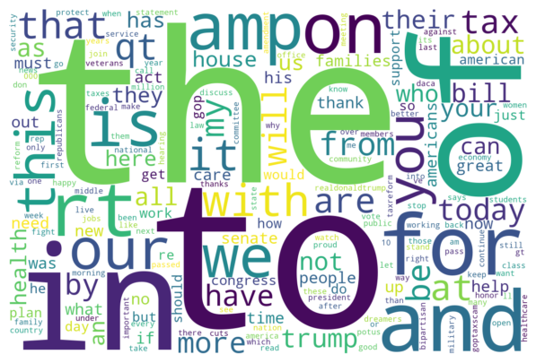

```python
from wordcloud import WordCloud
import matplotlib.pyplot as plt

# 根据词袋模型分析结果绘制词云图
wc = WordCloud(
    width=1200,
    height=800,
    background_color='white',
    #font_path='arial.ttf'
).generate_from_frequencies(word_freq)

# 显示词云图
plt.figure(figsize=(10, 5))
plt.imshow(wc, interpolation='bilinear')
plt.axis('off')
plt.show()
plt.savefig('wordcloud_twi.png', dpi=100)
```

# # 词袋模型

词袋模型（Bag of Words，简称 BoW）是自然语言处理（NLP）中常用的文本表示方法，它将文本转化为数值特征（向量），进而可以用于机器学习等高阶处理。词袋模型将语料转化为二维矩阵，横向为所有在训练数据中出现的不重复的词汇（word），纵向为语料各句子或文档（document）。

简单来说，词袋模型可以帮助大家计算词频。

```python
import pandas as pd
```

```python
#读取数据
text_ana=pd.read_csv('text_analysis_weibo.csv')
text_ana=text_ana.drop(['Unnamed: 0'],axis=1)#Unnamed:需要有空格
text_ana
```

|  | 标题/微博内容 | 点赞 | 转发 | 评论 | 账号昵称UID加密 | 粉丝数 | 关注数 | 地域 |
| --- | --- | --- | --- | --- | --- | --- | --- | --- |
| 0 | #高校通报教师图书馆打电话声音过大出言不逊#公道自在人心，谣言自在人心  | 0 | 0 | 0 | a2331b38901d62d2d9a20529177ef3b3 | 0 | 22 | 湖北 |
| 1 | 转发C | 0 | 0 | 0 | d6dc4470f51fce93cc0cbad8abf55a75 | 0 | 33 | 广西 |
| 2 | 【#刘雨昕运动者联濛#河山覆冰雪，健儿迎冬奥[金牌]全能唱跳不设限，运动联濛开新年🇨🇳 期待... | 0 | 0 | 0 | 372bc4782eb442b88035f920a7c1a68e | 6 | 85 | 广东 |
| 3 | 丁程鑫//@丁程鑫后援会官博:#丁程鑫[超话]# ✨#丁程鑫 二十成金筑梦鑫世界# 大年初一... | 0 | 0 | 0 | 6fe0d482bd3e78a3483e2a1d57f14ef2 | 75 | 1012 | 广东 |
| 4 | 诶，你们真不要脸诶。。。没资格宣传奥运。。。抵制抵制！ | 0 | 0 | 0 | 872380d71d6ee9130e8b49d331f2baa9 | 0 | 10 | 广东 |
| ... | ... | ... | ... | ... | ... | ... | ... | ... |
| 49995 | 935天气路况早知道 2022年3月2日 星期三 今日限行尾号3和8 8：00分发布 ... | 0 | 0 | 0 | 2231ab79796d569625633acafd9f1351 | 445 | 74 | 河南 |
| 49996 | 4月1日起，交通违法记分规则重大调整！ http://t.cn/A66zxfR0  | 0 | 0 | 0 | 91c9d380c1cc7811be5ee10ce510d77a | 842 | 54 | 甘肃 |
| 49997 | 转发C | 0 | 0 | 1 | 301771db13798e2dd493c02a44e59444 | 99 | 3433 | 江苏 |
| 49998 | 全体 甘肃车主注意 4月1日起，全面实施！ ... | 0 | 0 | 0 | NaN | 0 | 0 | 甘肃 |
| 49999 | 【南通司机注意！4月1日起，记分规则重大调整】驾车拨打、接听电话妨碍安全驾驶的，由一次性记... | 0 | 0 | 0 | 00ba855b51c9b06bd28abe9987d6e957 | 314265 | 342 | 江苏 |

50000 rows × 8 columns

# # # 数据预处理

```python
#分析语料
text=list(text_ana['标题/微博内容'])
text
```

```
['#高校通报教师图书馆打电话声音过大出言不逊#公道自在人心，谣言自在人心 \u200b\u200b',
 '转发C',
 '【#刘雨昕运动者联濛#河山覆冰雪，健儿迎冬奥[金牌]全能唱跳不设限，运动联濛开新年🇨🇳 期待全能音乐人@刘雨昕 与#运动者联濛#一起，为冬奥赛事助力加油！】',
 '丁程鑫//@丁程鑫后援会官博:#丁程鑫[超话]# ✨#丁程鑫 二十成金筑梦鑫世界# 大年初一锁定@北京卫视 和门面主舞@时代少年团-丁程鑫 一起过大年，拥抱冰雪，致敬冬奥！',
 '诶，你们真不要脸诶。。。没资格宣传奥运。。。抵制抵制！',
 '转发C',
 '#熊猫守护者##全面二创冰墩墩#北京冬奥会如火如荼地进行中，滚滚我的好朋友冰墩墩也十分活跃，看滚滚我做一组舒展运动，为中国健儿加油鼓劲儿！[嘻嘻][嘻嘻] http://t.cn/A6ilerDZ 视频来源：@桃花源生态保护基金会 \u200b\u200b\u200b',
 '转发C',
 '2022北京冬奥会加油！冰墩墩雪容融也非常可爱！期待我国奥运健儿们的精彩表现[开学季]#云支教迎冬奥# \u200b\u200b',
 '和@TFBOYS-易烊千玺 一起助力东奥！一起向未来！',
 '转发C',
 '[心]',
 '守护[心]',
 '#易烊千玺邀你唱响一起向未来# //@M28号星球:#易烊千玺邀你唱响一起向未来# 26.17',
 '//@翔霖神谕:感谢@爱奇艺 的分享。新年胜旧年，春妍惹绚烂，万事胜意与平安喜乐的祝福徒增和乐，@时代少年团-严浩翔 @时代少年团-贺峻霖  同少年关注北京台春晚，拥锦瑟年华岁岁。',
 '好棒[打call][打call][打call]//@只是叭呐呐:哇晒哇晒！厉害我顶起！！！#蔡徐坤代言燕京啤酒# //@蔡徐坤的大喇叭萱:#蔡徐坤[超话]# I#蔡徐坤代言燕京啤酒# 恭喜燕京啤酒，在北京冬奥会官方赞助商冬奥营销传播声量总榜单正式发布位列第三！和代言人@蔡徐坤 一起释放活力，点燃激情，喝彩冬奥！[干杯]',
 '转发C',
 '//@杰克涛:金牌稳了[笑而不语]',
 '转发C',
 '//@许佳琪kiki:#一起冬奥吧# 中国队加油呀⛽️',
 '转发C',
 '蹲',
 '转发',
 '#周深一起向未来高音太绝了#@卡布叻_周深 录制《一起向未来》花絮来了！这漂亮的高音简直绝绝子~#周深唱响一起向未来音乐短片#http://t.cn/A6iGRcUr \u200b\u200b',
 '#周深宝可梦25周年曲可梦#海角天涯我甘愿奉陪，赤子有梦任艰险不畏,烟雨若淡了，唯情深未了。@卡布叻_周深http://t.cn/A6ierQv2',
 'wzy…白白相信你了嗷',
 '📢',
 '和腾讯冬奥报道雪舞大使尹浩宇@INTO1-尹浩宇 一起为东奥写下美好祝福[心]愿冬奥健儿们在赛场上永远「带着热忱，相信着我能」[羞嗒嗒]#INTO1雪舞花式祝福大赛#[玉兔]#into1尹浩宇实力vocal#',
 '加油[赢牛奶]//@可口可乐后援会会长:#曾涵江rap实力# ☕ #曾涵江燃炸LIVESHOW#真棒真棒，继续努力✨💚💎@曾涵江和Cup',
 '转发C',
 '朱一龙啊[色]',
 '转发C',
 '转发C',
 '转发C',
 '转发C',
 '宝贝[开学季]',
 '#刘雨昕冬梦之约冰雪盛典#｜#刘雨昕加盟冬梦之约2#',
 '【#刘雨昕运动者联濛#脚踏赛场，逐梦北京；昕春初至万里山河，雨你相约助阵冬奥🏂 期待全能唱跳歌手@刘雨昕 与北京卫视#运动者联濛#产生的奇妙火花🔥】',
 '转发C',
 '//@默默昕小七:#刘雨昕运动者联濛#｜#运动者联濛#又来看刘雨昕@刘雨昕 啦！雨伞们一起关注北京冬奥会，🧊🔹http://t.cn/A6MN51Qh❄️💙学了解冬奥知识，为中国健儿加油！💙',
```

[output cut: 946 more lines]

```
 '转发C',
 '和恺恺一起向未来',
 '#运动者联濛# 不用劝了，世间唯有美食不可辜负！更何况是冬奥美食！你以为啥时候都能吃到啊～ http://t.cn/A6ieZbDB \u200b \u200b\u200b',
 '转发C',
 '[心]',
 '《张艺谋的作业》方希 冬奥会开闭幕式的惊艳， 让老谋子的这本记录早期摄影作品和2008年奥运会开幕式的“作业”又火了一把。  从国棉八厂四大才子，到奥运会、冬奥会开闭幕式总导演，老谋子是“幸运”的。但为什么他是“幸运”的？本书基本给出了答案，用笨功夫，下苦功夫，无他。 作者不是张艺谋的拥趸，只是客观的记录和展示。照片基本都是老谋子七十年代自学摄影时的习作，也是“破格”进入北电的敲门砖。 当当上一本已经炒到三五百了，还好咱看得起电子书[偷笑]值得一看#读书#',
 '//@两只脏南瓜:/#刘雨昕运动者联濛#｜#运动者联濛#又来看刘雨昕@刘雨昕 啦！雨伞们一起关注北京冬奥会，🧊🔹http://t.cn/A6MN51Qh❄️💙学了解冬奥知识，为中国健儿加油！',
 '[色]//@浅笑7373313338:http://t.cn/A6xXqxQl',
 '[亲亲]//@诺言很重别轻易许:http://t.cn/A6xwbtDu  .1',
 '[害羞]//@Lmoon尐帥:a',
 '//@健康与护理学院护理学2101班:@武昌理工学院护理学院 @健康与护理学院-信网部 [微笑]//@武昌理工学院护理学院:@武昌理工学院校团委 [太开心][太开心][太开心]',
 '低碳环保[打call]',
 '转发C',
 '[挤眼]//@hjf嘉伟:http://t.cn/A6xmKbzk',
 ...]
```

```python
import jieba
def word_segmentation(text):
    words=jieba.lcut(text)
    return ' '.join(words)
text_ana['标题/微博内容']=text_ana['标题/微博内容'].iloc[:100]\
.astype(str).apply(word_segmentation)
text_ana['标题/微博内容'].head()
```

```
Building prefix dict from the default dictionary ...
Loading model from cache /var/folders/kk/ylyfvmrj6zv853wrvp3s_0180000gn/T/jieba.cache
Loading model cost 0.323 seconds.
Prefix dict has been built successfully.
```

```
0    # 高校 通报 教师 图书馆 打电话 声音 过大 出言不逊 # 公道 自 在 人心 ， 谣言...
1                                                 转发 C
2    【 # 刘雨昕 运动 者 联 濛 # 河山 覆 冰雪 ， 健儿 迎 冬奥 [ 金牌 ] 全能...
3    丁程鑫 / / @ 丁程鑫 后援会 官博 : # 丁程鑫 [ 超话 ] #   ✨ # 丁程...
4        诶 ， 你们 真 不要脸 诶 。 。 。 没 资格 宣传 奥运 。 。 。 抵制 抵制 ！
Name: 标题/微博内容, dtype: object
```

```python
text=list(text_ana['标题/微博内容'].dropna())
text
```

```
['# 高校 通报 教师 图书馆 打电话 声音 过大 出言不逊 # 公道 自 在 人心 ， 谣言 自 在 人心   \u200b \u200b',
 '转发 C',
 '【 # 刘雨昕 运动 者 联 濛 # 河山 覆 冰雪 ， 健儿 迎 冬奥 [ 金牌 ] 全能 唱 跳 不 设限 ， 运动 联 濛 开 新年 🇨 🇳   期待 全能 音乐 人 @ 刘雨昕   与 # 运动 者 联 濛 # 一起 ， 为 冬奥 赛事 助力 加油 ！ 】',
 '丁程鑫 / / @ 丁程鑫 后援会 官博 : # 丁程鑫 [ 超话 ] #   ✨ # 丁程鑫   二十 成金筑梦鑫 世界 #   大年初一 锁定 @ 北京 卫视   和 门面 主舞 @ 时代 少年 团 - 丁程鑫   一起 过大年 ， 拥抱 冰雪 ， 致敬 冬奥 ！',
 '诶 ， 你们 真 不要脸 诶 。 。 。 没 资格 宣传 奥运 。 。 。 抵制 抵制 ！',
 '转发 C',
 '# 熊猫 守护者 ## 全面 二 创冰墩 墩 # 北京 冬奥会 如火如荼 地 进行 中 ， 滚滚 我 的 好 朋友 冰墩 墩 也 十分 活跃 ， 看 滚滚 我 做 一组 舒展 运动 ， 为 中国 健儿 加油 鼓 劲儿 ！ [ 嘻嘻 ] [ 嘻嘻 ]   http : / / t . cn / A6ilerDZ   视频 来源 ： @ 桃花源 生态 保护 基金会   \u200b \u200b \u200b',
 '转发 C',
 '2022 北京 冬奥会 加油 ！ 冰墩 墩 雪容融 也 非常 可爱 ！ 期待 我国 奥运健儿 们 的 精彩 表现 [ 开学 季 ] # 云 支教 迎 冬奥 #   \u200b \u200b',
 '和 @ TFBOYS - 易 烊 千玺   一起 助力 东奥 ！ 一起 向 未来 ！',
 '转发 C',
 '[ 心 ]',
 '守护 [ 心 ]',
 '# 易 烊 千玺 邀 你 唱响 一起 向 未来 #   / / @ M28 号 星球 : # 易 烊 千玺 邀 你 唱响 一起 向 未来 #   26.17',
 '/ / @ 翔霖 神谕 : 感谢 @ 爱奇艺   的 分享 。 新年 胜 旧年 ， 春妍 惹 绚烂 ， 万事 胜意 与 平安 喜乐 的 祝福 徒增 和 乐 ， @ 时代 少年 团 - 严浩翔   @ 时代 少年 团 - 贺峻霖     同 少年 关注 北京 台 春晚 ， 拥 锦瑟年华 岁 岁 。',
 '好棒 [ 打 call ] [ 打 call ] [ 打 call ] / / @ 只是 叭 呐 呐 : 哇 晒 哇 晒 ！ 厉害 我顶 起 ！ ！ ！ # 蔡 徐坤 代言 燕京啤酒 #   / / @ 蔡 徐坤 的 大 喇叭 萱 : # 蔡 徐坤 [ 超话 ] #   I # 蔡 徐坤 代言 燕京啤酒 #   恭喜 燕京啤酒 ， 在 北京 冬奥会 官方 赞助商 冬奥 营销 传播 声量 总 榜单 正式 发布 位列 第三 ！ 和 代言人 @ 蔡 徐坤   一起 释放 活力 ， 点燃 激情 ， 喝彩 冬奥 ！ [ 干杯 ]',
 '转发 C',
 '/ / @ 杰克 涛 : 金牌 稳 了 [ 笑 而 不语 ]',
 '转发 C',
 '/ / @ 许佳琪 kiki : # 一起 冬奥 吧 #   中国队 加油 呀 ⛽ ️',
 '转发 C',
 '蹲',
 '转发',
 '# 周深 一起 向 未来 高音 太绝 了 # @ 卡布 叻 _ 周深   录制 《 一起 向 未来 》 花絮 来 了 ！ 这 漂亮 的 高音 简直 绝绝子 ~ # 周深 唱响 一起 向 未来 音乐 短片 # http : / / t . cn / A6iGRcUr   \u200b \u200b',
 '# 周深宝 可梦 25 周年 曲可梦 # 海角天涯 我 甘愿 奉陪 ， 赤子 有梦任 艰险 不畏 , 烟雨 若淡 了 ， 唯 情深 未了 。 @ 卡布 叻 _ 周深 http : / / t . cn / A6ierQv2',
 'wzy … 白白 相信 你 了 嗷',
 '📢',
 '和 腾讯 冬奥 报道 雪舞 大使 尹浩宇 @ INTO1 - 尹浩宇   一起 为 东奥 写下 美好 祝福 [ 心 ] 愿 冬奥 健儿 们 在 赛场 上 永远 「 带 着 热忱 ， 相信 着 我 能 」 [ 羞嗒 嗒 ] # INTO1 雪舞 花式 祝福 大赛 # [ 玉兔 ] # into1 尹浩宇 实力 vocal #',
 '加油 [ 赢 牛奶 ] / / @ 可口可乐 后援会 会长 : # 曾 涵江 rap 实力 #   ☕   # 曾 涵江 燃炸 LIVESHOW # 真棒 真棒 ， 继续 努力 ✨ 💚 💎 @ 曾 涵江 和 Cup',
 '转发 C',
 '朱一龙 啊 [ 色 ]',
 '转发 C',
 '转发 C',
 '转发 C',
 '转发 C',
 '宝贝 [ 开学 季 ]',
 '# 刘雨昕 冬梦之约 冰雪 盛典 # ｜ # 刘雨昕 加盟 冬梦之约 2 #',
 '【 # 刘雨昕 运动 者 联 濛 # 脚踏 赛场 ， 逐梦 北京 ； 昕 春初 至 万里 山河 ， 雨 你 相约 助阵 冬奥 🏂   期待 全能 唱 跳 歌手 @ 刘雨昕   与 北京 卫视 # 运动 者 联 濛 # 产生 的 奇妙 火花 🔥 】',
 '转发 C',
 '/ / @ 默默 昕 小 七 : # 刘雨昕 运动 者 联 濛 # ｜ # 运动 者 联 濛 # 又 来看 刘雨昕 @ 刘雨昕   啦 ！ 雨伞 们 一起 关注 北京 冬奥会 ， 🧊 🔹 http : / / t . cn / A6MN51Qh ❄ ️ 💙 学 了解 冬奥 知识 ， 为 中国 健儿 加油 ！ 💙',
```

[output cut: 45 more lines]

```
 '/ / @ 刘雨昕 _ 超能力 UM 星球 : # 刘雨昕 运动 者 联 濛 #   🌧 冰雪 凝聚 热爱 ， 昕 光 照耀 未来 ✨ 和 刘雨昕 @ 刘雨昕   一起 为 冬奥 加油 ！ 为 冰雪 运动 喝彩 ！ 2 月 5 日晚 ， 锁定 北京 卫视 《 运动 者 联 濛 》 和 刘雨昕 一起 为 冬奥 健儿 加油 [ 赢 牛奶 ]',
 '转发 C',
 '转发 C',
 '转发 C',
 '# 什么 是 北京 冬奥 精神 # 一起 向 未来   \u200b \u200b',
 '转发 C',
 '高科技 ， 泪目 … …',
 '转发 C',
 '冰雪 绽放 魅力',
 '[ 色 ] / / @ 诺言 很 重别 轻易 许 : http : / / t . cn / A6xwbtDu     . 4',
 '/ / @ 爱 踢 答人 : 饭圈 是 你 妈 吗 什么 都 找 饭 圈 [ 汗 ]',
 '转发 C',
 '中国 代表团 已经 实现 了 单届 冬奥会 金牌 、 奖牌 最多 的 愿望 ， 北京 冬奥会 已经 成为 历史 上 最好 成绩 的 一届 冬奥会 了 # 娱乐 综艺 ## 明星 日常 #     http : / / t . cn / A66HQzUN   \u200b \u200b',
 '/ / @ 文轩 星系 : 感谢 @ 北京 台 春晚   分享 。 尽享 中华 之美 ， 共祝 冬奥 盛会 。 和 @ 时代 少年 团 - 宋亚轩   @ 时代 少年 团 - 刘耀文   一起 为 奥运健儿 加油 吧 ！',
 '/ / @ 李宇春 疯狂 工作室 : # 李宇春 时尚 COSMO5 月刊 封面 #   # 和 李宇春 的 一日 春游 #   @ 李宇春   登 COSMO   5 月刊 封面 。 “ 我 觉得 一个 很 鲜活 的 人 ， 他 不是 一个 单面 ， 反而 是 有 喜怒哀乐 的 。 让 人生 更加 丰富多彩 ， 我 觉得 也 算是 一种 有志 。 ”']
```

# # # 构建词袋模型

```python
from sklearn.feature_extraction.text import CountVectorizer
#初始化CounVectorizer
vectorizer=CountVectorizer()
#将文本数据转换为词袋特征矩阵
X=vectorizer.fit_transform(text)
#展示特征矩阵的形状
print('词袋特征矩阵的形状:',X.shape)
#展示词袋模型中的所有特征词
print('特征词列表:',vectorizer.get_feature_names_out())
```

```
词袋特征矩阵的形状: (100, 602)
特征词列表: ['0414' '1020' '167' '17' '18' '19' '2022' '25' '26' '50' 'a669n33f'
 'a66hqzun' 'a66v9mln' 'a6i5bc1o' 'a6ierqv2' 'a6igrcur' 'a6ikvewj'
 'a6ikxrlc' 'a6ilerdz' 'a6ipxoe0' 'a6jy3xv2' 'a6mn51qh' 'a6xwbtdu' 'an35'
 'c2021' 'call' 'cn' 'cosmo' 'cosmo5' 'cup' 'heytea' 'http' 'into1' 'kiki'
 'liveshow' 'lm' 'm28' 'mv' 'rap' 'tfboys' 'to19' 'um' 'vocal' 'wzy'
 'yyds' '一个' '一休' '一天' '一定' '一封' '一届' '一张' '一日' '一片' '一种' '一组' '一起' '一辈子'
 '丁哥' '丁程鑫' '万事' '万里' '三珩' '不仅' '不停' '不是' '不畏' '不要' '不要脸' '不语' '世界' '东奥'
 '东方' '东西' '东进' '严浩翔' '中华' '中国' '中国画' '中国队' '中央美术学院' '丰富多彩' '主舞' '之后' '之火'
 '之约' '之美' '了解' '二十' '产生' '京东' '人心' '人生' '什么' '他们' '代入' '代表团' '代言' '代言人'
 '以此' '休息' '优秀' '会长' '传播' '位列' '位送' '低沉' '你们' '你好' '便是' '保护' '信号' '健儿'
 '兄弟' '全能' '全面' '公道' '六个' '共祝' '关心' '关注' '关键' '其中' '养乐多' '兼好' '再说' '写下'
 '冠军' '冬天' '冬奥' '冬奥会' '冬季' '冬日' '冬梦之约' '冰墩' '冰壶' '冰雪' '准时' '凝聚' '出演'
 '出言不逊' '分享' '刘耀文' '刘雨昕' '刚刚开始' '创冰墩' '前辈' '加油' '加盟' '助力' '助威' '助阵' '努力'
 '劲儿' '勇士' '北京' '十八' '十八岁' '十六个' '十分' '十大' '千玺' '单人滑' '单届' '单身' '单面' '卡布'
 '卫视' '历史' '厉害' '原博' '去年' '参加' '反而' '发布' '只是' '可以' '可口可乐' '可惜' '可梦' '可爱'
 '可能' '名将' '后援会' '向前' '吸引' '告诉' '周年' '周深' '周深宝' '周深献声' '和尚' '和悦' '咪咕' '哥哥'
 '唱响' '喇叭' '喜乐' '喜怒哀乐' '喜欢' '喜爱' '喝彩' '嘎嘎' '嘻嘻' '四块' '回袖' '团内' '围观' '国家队'
 '图书馆' '场馆' '基金会' '增减' '墨墨' '声量' '声音' '多人' '大使' '大学' '大家' '大年初一' '大赛' '太太'
 '太帅' '太棒了' '太绝' '央视春晚' '夺冠' '奇妙' '奉陪' '奋力拼搏' '奖牌' '奥林匹克' '奥运' '奥运会'
 '奥运健儿' '好像' '好几遍' '好多' '好想' '好棒' '如火如荼' '娱乐' '守护' '守护者' '安全感' '宋亚轩' '宋小贺'
 '官博' '官方' '官配炎' '宝贝' '实力' '实现' '宣传' '害羞' '寒冬' '寻常' '封面' '小严' '小孩' '小张'
 '小心' '小炸们' '少女' '少年' '就是' '尹浩宇' '尽享' '居然' '展现' '山河' '工作室' '已经' '希望' '干杯'
 '平安' '年代' '年度' '广播' '开始' '开学' '开展' '开幕' '弟弟' '张哥' '张昊' '张真源' '当时' '录制'
 '影音' '很多' '很棒' '徐坤' '徒增' '微风' '心怀' '志愿者' '总是' '总能' '恬不知耻' '恭喜' '情深' '惊喜'
 '感受' '感谢' '愿望' '成为' '成功' '成员' '成绩' '成金筑梦鑫' '我们' '我国' '我顶' '所有' '所有人'
 '打电话' '护航' '报道' '抵制' '抵达' '拉满' '拥抱' '接力' '提醒' '支持' '支教' '收看' '教师' '文轩'
 '新年' '新春' '日常' '日晚' '日本' '旧年' '早点' '时代' '时候' '时刻' '时尚' '时间' '明天' '明星'
 '星星之火' '星球' '星系' '春初' '春天' '春妍' '春晚' '春游' '春风' '晚安' '曲可梦' '更加' '更是' '最多'
 '最好' '最美' '月刊' '有志' '有时' '有梦任' '朋友' '期待' '期待值' '未了' '未来' '本来' '本溪' '朱一龙'
 '李宇春' '杏奈川夏' '来源' '来看' '杰克' '林墨' '柴火' '桃花源' '梦想' '检察' '榜单' '欢迎' '歌声' '歌扇'
 '歌手' '正式' '步履' '每位' '比赛' '永不' '永远' '沦陷' '河山' '泪目' '活力' '活动' '活跃' '海地'
 '海角天涯' '涵江' '深深' '清唱' '温暖' '温柔' '滚滚' '满满' '漂亮' '激动' '激情' '火炬' '火花' '点燃'
 '烟雨' '热忱' '热情高涨' '热爱' '热闹' '热雪浪' '照亮' '照耀' '照顾' '熄灭' '熊猫' '熟悉' '燃炸' '燎原'
 '燕京啤酒' '爱丽丝' '爱喝' '爱奇艺' '牛奶' '献给' '玉兔' '现在' '理想' '甘愿' '生态' '生日' '生日快乐'
 '生活' '生风' '电视台' '男子' '疯狂' '白白' '盛会' '盛典' '直播' '相信' '相约' '看不到' '真棒' '真的'
 '眼红' '知识' '知识产权' '短片' '破冰' '祝福' '神谕' '福利' '离开' '秋月' '突然' '窗似' '第一个' '第一次'
 '第三' '答人' '简直' '算是' '粉丝' '精彩' '精彩纷呈' '精神' '绅士' '结弦' '结弦日' '结束' '结果' '绚烂'
 '绝绝子' '继续' '综艺' '绽放' '罗一舟' '美好' '羞嗒' '羽生' '翔霖' '考上' '而行' '聆听' '聚首' '胜意'
 '脚踏' '腾讯' '自信' '自己' '至极' '致命' '致敬' '舒展' '舞台' '舞衫' '艰险' '花式' '花样滑冰' '花滑'
 '花絮' '若淡' '获得' '营销' '萧薰儿' '薯条' '虎虎生威' '行动' '衣物' '表现' '观看' '视频' '觉得' '解说'
 '认可' '训练' '记得' '许佳琪' '设限' '话剧' '诬蔑' '说话' '诺言' '谢谢' '谣言' '谷爱凌' '贺峻霖' '资格'
 '赛事' '赛前' '赛场' '赞助商' '赤子' '赤子之心' '超能力' '超话' '越来越' '趣事' '身上' '身体' '转发'
 '轻易' '达人小墨' '过大' '过大年' '迎接' '运动' '还要' '这个' '进行' '追梦' '逐梦' '通报' '造谣' '那个'
 '释放' '重别' '金牌' '铁流' '铃子' '锁定' '锦瑟年华' '门面' '闭幕式' '问候' '降温' '随便' '雨伞' '雪容融'
 '雪舞' '雪花' '青年' '非常' '面前' '音乐' '风禾尽起' '飞快' '飞扬' '饭圈' '首都体育馆' '马哥' '马铃'
 '高校' '高科技' '高音' '高高的' '魅力' '鲜活' '默默' '龚俊']
```

```python
#词袋矩阵，每一行每个词出现几次
list(X.toarray())
```

[output not shown]

[output cut: 2785 more lines]

# # # 词频统计

```python
#获取词汇表
feature_words=vectorizer.get_feature_names_out()
#计算词频
word_freq=dict(zip(feature_words,X.sum(axis=0).A1))
```

```python
# 词袋模型中不重复的词汇的数量
len(word_freq)
```

```
602
```

```python
sorted(word_freq.items(),key=lambda X: X[1],reverse=True)
```

```
[('转发', 33),
 ('冬奥', 30),
 ('一起', 29),
 ('北京', 25),
 ('刘雨昕', 20),
 ('运动', 18),
 ('加油', 17),
 ('少年', 14),
 ('cn', 13),
 ('http', 13),
 ('冬奥会', 12),
 ('未来', 12),
 ('冰雪', 11),
 ('健儿', 10),
 ('宋亚轩', 10),
 ('时代', 10),
 ('call', 9),
 ('期待', 8),
 ('中国', 7),
 ('全能', 6),
 ('分享', 6),
 ('徐坤', 6),
 ('我们', 6),
 ('超话', 6),
 ('into1', 5),
 ('丁程鑫', 5),
 ('冰墩', 5),
 ('努力', 5),
 ('周深', 5),
 ('感谢', 5),
 ('林墨', 5),
 ('真的', 5),
 ('自己', 5),
 ('金牌', 5),
 ('音乐', 5),
 ('关注', 4),
 ('助力', 4),
 ('卫视', 4),
 ('后援会', 4),
 ('唱响', 4),
```

[output cut: 547 more lines]

```
 ('青年', 1),
 ('非常', 1),
 ('风禾尽起', 1),
 ('飞快', 1),
 ('飞扬', 1),
 ('饭圈', 1),
 ('首都体育馆', 1),
 ('马哥', 1),
 ('马铃', 1),
 ('高校', 1),
 ('高科技', 1),
 ('高高的', 1),
 ('鲜活', 1),
 ('默默', 1),
 ('龚俊', 1)]
```

# # # 词云图

```python
import matplotlib.pyplot as plt
from matplotlib import font_manager

for font in font_manager.fontManager.ttflist:
    # 查看字体名以及对应的字体文件名
    print(font.name, '-', font.fname)
```

[output not shown]

[output cut: 340 more lines]

[output not shown]

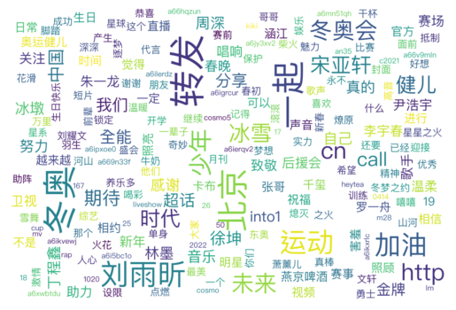

```python
# 根据词袋模型分析结果绘制词云图
from wordcloud import WordCloud
import matplotlib.pyplot as plt

wordcloud = WordCloud(
    font_path='/System/Library/Fonts/PingFang.ttc',  # 指定中文字体文件路径
    background_color='white',  # 设置背景颜色
    width=1200,
    height=800,
    max_words=200,  # 设置最大显示的词数
    max_font_size=100  # 设置字体最大值
).generate_from_frequencies(word_freq)

# 显示词云图
plt.imshow(wordcloud, interpolation='bilinear')
plt.axis('off')
plt.show()
```

# 作业数据集分析

数据集说明：因为爬虫技术限制，还有人民日报关于双减的微博仅19条，文本内容过少，故本研究不再研究人民日报微博数据，而是换成了其他数据。官方舆论场数据为中华人民共和国教育部官网，以“双减”为关键词搜索，并抓取共500条相关数据，命名为“官方双减数据”。民间舆论场数据为微博数据，以“双减”为关键词搜索，共抓取最新5000条相关数据，命名为“民间双减数据”。

# # 官方双减数据分析

```python
import pandas as pd
```

```python
#读取数据
text_ana=pd.read_csv('官方双减数据.csv')
#text_ana=text_ana.drop(['Unnamed: 0'],axis=1)#Unnamed:需要有空格
text_ana
```

|  | 标题 | 标题链接 | title | txt | content | content1 | txt1 | 文 号 |
| --- | --- | --- | --- | --- | --- | --- | --- | --- |
| 0 | ...中央办公厅 国务院办公厅印发《关于进一步减轻义务教育阶段学生作业负担和校外培训负担的意... | http://www.moe.gov.cn/jyb_xxgk/moe_1777/moe_17... | 公开 | NaN | NaN | 教育部-2021-07-24 | NaN | NaN |
| 1 | 坚决贯彻中央决策部署 深入推进“双减”工作——教育部有关负责人就《关于进一步减轻义务教育阶段... | http://www.moe.gov.cn/jyb_xwfb/s271/202107/t20... | 新闻 | 全链条推进“双减”工作。三是综合治理。建立“双减”工作专门协 。 问：“双减”工作的总体目标... | 教育部-2021-07-24 | NaN | NaN | NaN |
| 2 | 专家解读《关于进一步减轻义务教育阶段学生作业负担和校外培训负担的意见》 | http://www.moe.gov.cn/jyb_xwfb/s5147/202107/t2... | 新闻 | “双减”目标如何实现 2021-07-26 来源：《中国青年报》收藏 担和校外培训负担（以下... | 教育部-2021-07-26 | NaN | NaN | NaN |
| 3 | 教育部办公厅关于学习推广北京等地经验做法进一步做好“双减”工作的通知 | http://www.moe.gov.cn/srcsite/A29/202109/t2021... | 公开 | NaN | NaN | 教育部-2021-08-26 | 。 现将北京等四地近期开展“双减”工作的典型做法印发给你们， 福建省“点题整治”校外培训 4... | 教监管厅函〔2021〕5号 |
| 4 | 以人民为中心，将“双减”落到实处——专家解读《关于进一步减轻义务教育阶段学生作业负担和校外培... | http://www.moe.gov.cn/jyb_xwfb/s5147/202107/t2... | 新闻 | 怎样将“双减”工作落到实处 记者采访了多位专家。 “双减”事关国之大计党之大计 以人民为中心... | 教育部-2021-07-26 | NaN | NaN | NaN |
| ... | ... | ... | ... | ... | ... | ... | ... | ... |
| 495 | 强化培训机构预收费风险管控 坚决防止侵害群众利益行为——教育部有关部门负责人就《关于加强校外... | http://www.moe.gov.cn/jyb_xwfb/s271/202110/t20... | 新闻 | 于进一步减轻义务教育阶段学生作业负担和校外培训负担的意见》（ 务院办公厅印发《意见》，对“双... | 教育部-2021-10-29 | NaN | NaN | NaN |
| 496 | 教育部办公厅关于开展县域义务教育优质均衡创建工作的通知 | http://www.moe.gov.cn/srcsite/A06/s3321/202112... | 公开 | NaN | NaN | 教育部-2021-11-29 | 群众所急所需所盼，全面落实“双减”任务，大力深化综合改革，加 综合改革的良好氛围，在落实“双... | 教基厅函〔2021〕43号 |
| 497 | 教育部办公厅关于做好2022年暑期校外培训治理有关工作的通知 | http://www.moe.gov.cn/srcsite/A29/202206/t2022... | 公开 | NaN | NaN | 教育部-2022-06-23 | 教育局： 2022年暑期是“双减”后的第二个暑期。前期校外培 一、专门作出安排部署。各地教育... | 教监管厅函〔2022〕12号 |
| 498 | 教育部部署2024年教育工作重点任务 | http://www.moe.gov.cn/jyb_xwfb/s5147/202401/t2... | 新闻 | 教育提质扩优工程，巩固深化“双减”成果。 职业教育方面，会议... | 教育部-2024-01-12 | NaN | NaN | NaN |
| 499 | 依法查处校外培训违法行为 不折不扣落实中央决策部署——教育部校外教育培训监管司负责人就《校外... | http://www.moe.gov.cn/jyb_xwfb/s271/202309/t20... | 新闻 | 于进一步减轻义务教育阶段学生作业负担和校外培训负担的意见》（ 以下简称《“双减”意见》），依... | 教育部-2023-09-12 | NaN | NaN | NaN |

500 rows × 8 columns

# # # 数据预处理

```python
#分析语料
text=list(text_ana['txt'])
text
```

```
[nan,
 '全链条推进“双减”工作。三是综合治理。建立“双减”工作专门协 。 问：“双减”工作的总体目标是什么 答：“双减”工作的总体...',
 '“双减”目标如何实现 2021-07-26 来源：《中国青年报》收藏 担和校外培训负担（以下简称“双减”）工作，取得了积极成效。但...',
 nan,
 '怎样将“双减”工作落到实处 记者采访了多位专家。 “双减”事关国之大计党之大计 以人民为中心，将“双减”落到实处 2021-07-26 来源：《中国教育报》收藏...',
 '，指导学校做好“双减”有关工作。落实“双减”工作，地方教育部 实。 确保“双减”政策落实落地 “推进实施 双减 工作是党中...',
 '版权所有 中华人民共和国教育部 中文域名 教育部 政务 京ICP...',
 '，明确家校社协同责任。推进“双减”工作，学校的主体作用不可或 属实验中学校长姚跃林表示，“双减”落实落地离不开基层学校、一线教师。...',
 '如何确保“双减”工作取得实效 《意见》提出，加强党对“双减”工作 担和校外培训负担（以下简称“双减”）工作，取得了积极成效。但...',
 nan,
 '减轻义务教育阶段学生作业负担和校外培训负担 李克强王沪宁韩正出席 审议通过了 关于完善科技成果评价机制的指导意见 关于进一步减轻义务教育阶段学生作业负担和校外培训负担的意见...',
 '要求。 “双减”一年来，一个共识已然形成：“双减”是对人民的 心用情用力写好 双减 这篇大文章，确保 双减 工作目标如期实现。”（本报记者...',
 nan,
 nan,
 '锚定三年目标，攻坚克难，确保如期完成中央“双减”任务 ——教育部召开全国“双减”工作视频调度会 来源：教育部收藏 为深入贯彻落实党中央关于“双减”工作的决策部署，锚定三年目...',
 nan,
 nan,
 nan,
 nan,
 nan,
 nan,
 '根据《关于进一步减轻义务教育阶段学生作业负担和校外培训负担的意见》中 公室于2021年8月建立了“双减”工作专项督导半月通报制度。...',
 '于进一步减轻义务教育阶段学生作业负担和校外培训负担的意见》等...',
 '于进一步减轻义务教育阶段学生作业负担和校外培训负担的意见》，...',
 '北京出台义务教育“双减”措施 大比例促进教师流动 提高课后服务的水平 获悉：为减轻义务教育阶段学生作业负担和校外培训负担，日前，北...',
 nan,
 '“双减”明白卡 2022-02-25 来源：教育部收藏 教育部校外教育培训监管司 教育部校外教育培训监管司 一、什么是“双减” 2021年7月，中共中央...',
 '教育部召开全国“双减”工作推进会暨“双减”工作专门协调机制全体会议 7月21日，教育部在京召开全国“双减”工作推进会暨“双减”工作专门协调机制...',
 nan,
 '海南省委书记在海口调研“双减”工作 协同推进教育质量提升和阳光快乐教育 况昌勋）日前，海南省委书记沈晓明在海口市调研减轻义务教育阶段学生作业负担和校外培训负担工作，强调...',
 '四川出台14条举措深入推进“双减” 2022-05-23 来源：《中国教育报》收藏 于进一步减轻义务教育阶段学生作业负担和校外培训负担的实施方案...',
 '二是建立“双减”专项督导半月通报制度。 三是将“双减”工作纳入省级政府履职督导评价。 育督导局一级巡视员胡延品就“双减”督导的相关事项作了通报。...',
 '教育部召开全国“双减”试点地区工作推进会 2021-10-19 近日，为深入贯彻落实《关于进一步减轻义务教育阶段学生作业负担和校外培训负担的意见》精...',
 '会办公室就“双减”设立专门举报平台，并建立“双减”专项督导半 国务院教育督导办就“双减”设立专门举报平台 新华社北京8月3...',
 '教育部相关司局负责同志深入阐述了“双减”政策的出台背景和重大意义，通报了“双减”工作的 教育部举办第二期“双减”工作全国视频培训班 2021-11-16...',
 '张盖伦）加强“双减（减轻义务教育阶段学生作业负担和校外培训负担）”督 “双减”被列为2021年教育督导工作“一号工程” 科技日报北京8月30日电（记者...',
 '完善措施，推动“双减”政策落实落细。 “双减”，首先是减轻义 作业减量增效，校外培训压减 推动“双减”政策落实落细 2021-11-04...',
 '为督促各地切实贯彻落实中办国办《关于进一步减轻义务教育阶段学生作业负担和校外培训负担的意见》， 公室印发专门通知，拟对各省“双减”工作落实进度每半月通报一次。...',
 nan,
 '“双减”助力教育良好生态 2021-07-30 来源：《人民日报》收藏 于进一步减轻义务教育阶段学生作业负担和校外培训负担的意见》，...',
```

[output cut: 445 more lines]

```
 '于进一步减轻义务教育阶段学生作业负担和校外培训负担的意见》，...',
 '《意见》出台的背景是什么 答：“双减”是党中央、国务院作出的重大 于进一步减轻义务教育阶段学生作业负担和校外培训负担的意见》（...',
 '国家“双减”政策实施以来，昌图县教育局坚持以习近平新时代中国 一是减轻课业负担。出台了《昌图县进一步减轻义务教育阶段学生作业负担和校外培训负担的实施方案...',
 '补齐学校“五育”短板，巩固“双减”战果，强化创新精神和实践能...',
 nan,
 '校外培训治理是“双减”工作的重要一环。2021年7月，中共中 于进一步减轻义务教育阶段学生作业负担和校外培训负担的意见》，...',
 nan,
 '育人水平。要抓实扩优提质、“双减”、乡村教育、书记校长能力提...',
 nan,
 '《关于进一步减轻义务教育阶段学生作业负担和校外培训负担的意见》明...',
 '于进一步减轻义务教育阶段学生作业负担和校外培训负担的意见》（ 务院办公厅印发《意见》，对“双减”工作作出全面部署，明确要求...',
 nan,
 nan,
 '教育提质扩优工程，巩固深化“双减”成果。 职业教育方面，会议...',
 '于进一步减轻义务教育阶段学生作业负担和校外培训负担的意见》（ 以下简称《“双减”意见》），依法深化校外培训治理，近日，教育...']
```

```python
import jieba
def word_segmentation(text):
    words=jieba.lcut(text)
    return ' '.join(words)
text_ana['txt']=text_ana['txt'].iloc[:100]\
.astype(str).apply(word_segmentation)
text_ana['txt'].head()
```

```
0                                                  nan
1    全 链条 推进 “ 双减 ” 工作 。 三是 综合治理 。 建立 “ 双减 ” 工作 专门 ...
2    “ 双减 ” 目标 如何 实现   2021 - 07 - 26   来源 ： 《 中国青年...
3                                                  nan
4    怎样 将 “ 双减 ” 工作 落到实处   记者 采访 了 多位 专家 。   “ 双减 ”...
Name: txt, dtype: object
```

```python
text=list(text_ana['txt'].dropna())
text
```

```
['nan',
 '全 链条 推进 “ 双减 ” 工作 。 三是 综合治理 。 建立 “ 双减 ” 工作 专门 协   。   问 ： “ 双减 ” 工作 的 总体目标 是 什么   答 ： “ 双减 ” 工作 的 总体 ...',
 '“ 双减 ” 目标 如何 实现   2021 - 07 - 26   来源 ： 《 中国青年报 》 收藏   担 和 校外 培训 负担 （ 以下 简称 “ 双减 ” ） 工作 ， 取得 了 积极 成效 。 但 ...',
 'nan',
 '怎样 将 “ 双减 ” 工作 落到实处   记者 采访 了 多位 专家 。   “ 双减 ” 事关 国之 大计 党 之 大计   以 人民 为 中心 ， 将 “ 双减 ” 落到实处   2021 - 07 - 26   来源 ： 《 中国 教育 报 》 收藏 ...',
 '， 指导 学校 做好 “ 双减 ” 有关 工作 。 落实 “ 双减 ” 工作 ， 地方 教育部   实 。   确保 “ 双减 ” 政策 落实 落地   “ 推进 实施   双减   工作 是 党 中 ...',
 '版权所有   中华人民共和国教育部   中文 域名   教育部   政务   京 ICP ...',
 '， 明确 家校 社 协同 责任 。 推进 “ 双减 ” 工作 ， 学校 的 主体作用 不可 或   属 实验 中学校长 姚跃林 表示 ， “ 双减 ” 落实 落地 离不开 基层 学校 、 一线 教师 。 ...',
 '如何 确保 “ 双减 ” 工作 取得实效   《 意见 》 提出 ， 加强 党 对 “ 双减 ” 工作   担 和 校外 培训 负担 （ 以下 简称 “ 双减 ” ） 工作 ， 取得 了 积极 成效 。 但 ...',
 'nan',
 '减轻 义务教育 阶段 学生 作业负担 和 校外 培训 负担   李克强 王沪宁 韩正 出席   审议 通过 了   关于 完善 科技成果 评价 机制 的 指导 意见   关于 进一步 减轻 义务教育 阶段 学生 作业负担 和 校外 培训 负担 的 意见 ...',
 '要求 。   “ 双减 ” 一年 来 ， 一个 共识 已然 形成 ： “ 双减 ” 是 对 人民 的   心用情 用力 写 好   双减   这篇大 文章 ， 确保   双减   工作 目标 如期 实现 。 ” （ 本报记者 ...',
 'nan',
 'nan',
 '锚定 三年 目标 ， 攻坚克难 ， 确保 如期完成 中央 “ 双减 ” 任务   — — 教育部 召开 全国 “ 双减 ” 工作 视频 调度会   来源 ： 教育部 收藏   为 深入 贯彻落实 党中央 关于 “ 双减 ” 工作 的 决策 部署 ， 锚定 三年 目 ...',
 'nan',
 'nan',
 'nan',
 'nan',
 'nan',
 'nan',
 '根据 《 关于 进一步 减轻 义务教育 阶段 学生 作业负担 和 校外 培训 负担 的 意见 》 中   公室 于 2021 年 8 月 建立 了 “ 双减 ” 工作 专项 督导 半月 通报制度 。 ...',
 '于 进一步 减轻 义务教育 阶段 学生 作业负担 和 校外 培训 负担 的 意见 》 等 ...',
 '于 进一步 减轻 义务教育 阶段 学生 作业负担 和 校外 培训 负担 的 意见 》 ， ...',
 '北京 出台 义务教育 “ 双减 ” 措施   大 比例 促进 教师 流动   提高 课后 服务 的 水平   获悉 ： 为 减轻 义务教育 阶段 学生 作业负担 和 校外 培训 负担 ， 日前 ， 北 ...',
 'nan',
 '“ 双减 ” 明白卡   2022 - 02 - 25   来源 ： 教育部 收藏   教育部 校外 教育 培训 监管司   教育部 校外 教育 培训 监管司   一 、 什么 是 “ 双减 ”   2021 年 7 月 ， 中共中央 ...',
 '教育部 召开 全国 “ 双减 ” 工作 推进 会 暨 “ 双减 ” 工作 专门 协调 机制 全体会议   7 月 21 日 ， 教育部 在 京 召开 全国 “ 双减 ” 工作 推进 会 暨 “ 双减 ” 工作 专门 协调 机制 ...',
 'nan',
 '海南 省委书记 在 海口 调研 “ 双减 ” 工作   协同 推进 教育 质量 提升 和 阳光 快乐 教育   况昌勋 ） 日前 ， 海南 省委书记 沈晓明 在 海口市 调研 减轻 义务教育 阶段 学生 作业负担 和 校外 培训 负担 工作 ， 强调 ...',
 '四川 出台 14 条 举措 深入 推进 “ 双减 ”   2022 - 05 - 23   来源 ： 《 中国 教育 报 》 收藏   于 进一步 减轻 义务教育 阶段 学生 作业负担 和 校外 培训 负担 的 实施方案 ...',
 '二是 建立 “ 双减 ” 专项 督导 半月 通报制度 。   三是 将 “ 双减 ” 工作 纳入 省级 政府 履职 督导 评价 。   育 督导 局 一级 巡视员 胡延品 就 “ 双减 ” 督导 的 相关 事项 作 了 通报 。 ...',
 '教育部 召开 全国 “ 双减 ” 试点 地区 工作 推进 会   2021 - 10 - 19   近日 ， 为 深入 贯彻落实 《 关于 进一步 减轻 义务教育 阶段 学生 作业负担 和 校外 培训 负担 的 意见 》 精 ...',
 '会 办公室 就 “ 双减 ” 设立 专门 举报 平台 ， 并 建立 “ 双减 ” 专项 督导 半   国务院 教育 督导 办 就 “ 双减 ” 设立 专门 举报 平台   新华社 北京 8 月 3 ...',
 '教育部 相关 司局 负责同志 深入 阐述 了 “ 双减 ” 政策 的 出台 背景 和 重大意义 ， 通报 了 “ 双减 ” 工作 的   教育部 举办 第二期 “ 双减 ” 工作 全国 视频 培训班   2021 - 11 - 16 ...',
 '张盖伦 ） 加强 “ 双减 （ 减轻 义务教育 阶段 学生 作业负担 和 校外 培训 负担 ） ” 督   “ 双减 ” 被 列为 2021 年 教育 督导 工作 “ 一号 工程 ”   科技日报 北京 8 月 30 日电 （ 记者 ...',
 '完善 措施 ， 推动 “ 双减 ” 政策 落实 落细 。   “ 双减 ” ， 首先 是 减轻 义   作业 减量 增效 ， 校外 培训 压减   推动 “ 双减 ” 政策 落实 落细   2021 - 11 - 04 ...',
 '为 督促 各地 切实 贯彻落实 中办国办 《 关于 进一步 减轻 义务教育 阶段 学生 作业负担 和 校外 培训 负担 的 意见 》 ，   公室 印发 专门 通知 ， 拟 对 各省 “ 双减 ” 工作 落实 进度 每 半月 通报 一次 。 ...',
 'nan',
 '“ 双减 ” 助力 教育 良好 生态   2021 - 07 - 30   来源 ： 《 人民日报 》 收藏   于 进一步 减轻 义务教育 阶段 学生 作业负担 和 校外 培训 负担 的 意见 》 ， ...',
```

[output cut: 45 more lines]

```
 '“ 双减 ” 政策 落地 后 首个 开学日 ， 记者 直击 — —   新学期   新气象   2021 - 09 - 02   展 ， 朱奕天 同学 满怀 期待 。   “ 双减 ” 政策 （ 指 减轻 义务教育 阶段 学 ...',
 '贯彻落实 “ 双减 ” 政策   修订 培训 合同 示范 文本   2021 - 10 - 13   为了 贯彻落实 《 关于 进一步 减轻 义务教育 阶段 学生 作业负担 和 校外 培训 负担 的 意见 》 （ 中办发 ...',
 '“ 双减 ” 一年 来 ， 四川 坚持 校外 严格管理 和 校内 提质 增效 协同 发力 — —   这是 四川 天府 新区 学生 暑期 托管 的 丰富 生活 。   作为 “ 双减 ” 课后 服务 的 延伸 ， 四川 天府 新 ...',
 '— — 聚焦 “ 双减 ” 落地 系列报道 之一   2021 - 09 - 08   来源 ： 《 中国 教育 报 》   9 月 开学 后 ， 家住 宁波 的 家长 史 女士 松 了 一口气 ， 随着 “ 双减 ” 政策 落地 ， 学校 课后 托管 的 开 ...',
 'nan',
 '业 健康 发展 。   “ 双减 ” 主战场 在 校内   “   双减   需要 政府 和 社会   北京 多 部门 协同 监管 、 校内 校外 双向 发力 落实 “ 双减 ” — —   治理 校外 培训 机构 乱象 动真格 ...',
 '训 负担 ， 以 “ 双减 ” 的 决心 体现 为民 的 初心 ， 以 “ 双减 ” 的 成效 展示   。 要 加强 党 对 “ 双减 ” 工作 的 全面 领导 ， 将 “ 双减 ” 工作 列入 各级 党 ...',
 '所 未有 的 “ 双减 ” 之战 迅即 席卷全国 。 短短 百天 ， “ 双减 ” 力度 之大   这是 一场 必须 要 打 的 “ 双减 ” 之战 ， 这是 一场 必须 打赢 的 “ 双减 ” 之战 。   第一章 ...',
 '广州市 成立 市委书记 任组长 的 市 “ 双减 ” 工作 领导小组 ， 市 教育局 出台 党建 引领 “ 双减 ” 落地 见   南通市 9 个 城市 被 确定 为 全国 “ 双减 ” 试点 地区 ， 一场 基础教育 改革 创新 的 号角 就此 吹响 。 ...',
 '。   各地 探索 创新 “ 双减 ” 管理 新举措   “ 双减 ” 政策 出台 后 ， 各地   聚焦点   基础教育 “ 双减 ” 工作 监测 平台 直报 信息 显示 ， 截至 9 月 2 ...',
 '国务院 教育 督导 委员会 办公室 、 教育部 教育 督导 局   一 、 关于 “ 双减 ” 督导   加强 “ 双减 ” 督导 ， 是 中央 减轻 义   ， 是 推动 “ 双减 ” 各项政策 落地 见效 的 重要 举措 。 “ 双减 ” 督导 措施 和 开展 的 工作 ， 主要 有 六项 。 ...',
 '“ 双减 ” 后 的 “ 少 ” 与 “ 多 ”   — — “ 双减 ” 后 首个 学期 有 这些 收获   2022 - 01 - 18   来源 ： 新华网 收藏   “ 双减 ” 后 的 首个 学期 即将 结束 。 这个 ...',
 'nan',
 'nan',
 '于 进一步 减轻 义务教育 阶段 学生 作业负担 和 校外 培训 负担 的 意见 》 《   《 意见 》 明确提出 要 通过 3 至 5 年 努力 ， 在 教育 “ 双减 ” 中 做好 科学 教育 加法 的 各项 措 ...']
```

# # # 构建词袋模型

```python
from sklearn.feature_extraction.text import CountVectorizer
#初始化CounVectorizer
vectorizer=CountVectorizer()
#将文本数据转换为词袋特征矩阵
X=vectorizer.fit_transform(text)
#展示特征矩阵的形状
print('词袋特征矩阵的形状:',X.shape)
#展示词袋模型中的所有特征词
print('特征词列表:',vectorizer.get_feature_names_out())
```

```
词袋特征矩阵的形状: (100, 582)
特征词列表: ['01' '02' '03' '04' '05' '06' '07' '08' '09' '10' '11' '12' '13' '14'
 '16' '17' '18' '19' '2021' '2022' '2023' '21' '22' '23' '24' '25' '26'
 '29' '30' '31' '487' '8000' 'icp' 'nan' '一个' '一口气' '一号' '一场' '一年' '一是'
 '一次' '一系列' '一级' '一线' '三年' '三是' '上学' '上海' '上线' '不久' '不可' '不断完善' '不是' '不过'
 '专家' '专报' '专班' '专门' '专项' '严控' '严查' '严格管理' '中共中央' '中共中央办公厅' '中办发' '中办国办'
 '中华人民共和国教育部' '中国' '中国科协' '中国青年报' '中央' '中学校长' '中小学' '中小学生' '中心' '中文' '中肩'
 '丰富' '为了' '为民' '主体作用' '主战场' '主要' '主题' '举办' '举报' '举措' '义务教育' '之一' '之二'
 '之前' '之基' '之大' '之战' '习近平' '乱象' '了解' '事件' '事关' '事项' '二是' '五次' '交流' '人人'
 '人民' '人民日报' '什么' '今年' '代表' '以下' '以来' '任务' '任组长' '会议' '体现' '体系' '作业'
 '作业负担' '作为' '使命' '促进' '保障' '信息' '修订' '做好' '健康' '充分认识' '充实' '光明日报' '党中央'
 '党史' '党和国家' '党建' '全体会议' '全国' '全国人大' '全面' '全面落实' '公室' '公布' '六项' '共识' '关于'
 '关注' '关系' '内容' '内蒙古' '决心' '决策' '况昌勋' '准确' '减轻' '减量' '几何' '出台' '出席' '出现'
 '切实' '切身利益' '列为' '列入' '创新' '初心' '利器' '利用' '制度' '力度' '办公室' '加强' '加法' '动真格'
 '助力' '助推' '努力' '包括' '北京' '北京市' '十三届' '十大' '半月' '协同' '协调' '南通市' '印发' '即将'
 '历史' '压减' '压力' '压实' '及时' '双减' '双向' '发力' '发展' '发布' '发现' '取得' '取得实效' '受到'
 '受理' '变化' '召开' '号角' '司局' '各地' '各校' '各省' '各级' '各项' '各项政策' '合力' '合同' '同学'
 '同时' '启动' '吹响' '周报' '四川' '回归' '回望' '国之' '国办' '国务院' '国务院办公厅' '地区' '地方'
 '坚决' '坚持' '城市' '域名' '培养人才' '培训' '培训班' '基层' '基础教育' '增效' '多位' '多维' '大计'
 '天府' '女士' '如何' '如期' '如期完成' '委员会' '姚跃林' '学习' '学前' '学期' '学校' '学生' '学科' '宁波'
 '完善' '实施' '实施方案' '实现' '实验' '审议' '宣传' '家住' '家校' '家长' '寒假' '尝试' '就此' '层层'
 '展示' '履职' '履行' '山东' '山东省' '巡视员' '工作' '工程' '巨大' '已然' '市委书记' '带来' '席卷全国'
 '平台' '年度' '广州市' '广泛' '延伸' '建立' '建议' '开出' '开学' '开学日' '开展' '引领' '张盖伦' '强化'
 '强调' '形成' '心用情' '必胜信念' '必须' '快乐' '怎样' '思想' '思想认识' '思考' '总书记' '总体' '总体目标'
 '意见' '成效' '成立' '成长' '截至' '才能' '扎实' '打赢' '打造' '托管' '扛起' '批示' '把握' '投诉'
 '报送' '担负起' '指出' '指导' '指标' '指示' '按照' '探索' '推动' '推进' '措施' '提出' '提升' '提质'
 '提高' '撰写' '收到' '收获' '收藏' '改变' '改革' '攻坚克难' '攻坚战' '放学' '政务' '政府' '政治' '政策'
 '故事' '教学管理' '教师' '教育' '教育厅' '教育局' '教育部' '教育领域' '文件精神' '文本' '文章' '新举措'
 '新区' '新华社' '新华网' '新学期' '新气象' '新闻' '方案' '施策' '无法' '日前' '日电' '时间' '明白卡'
 '明确' '明确提出' '显示' '暑期' '最终' '有关' '有效' '服务' '期待' '未有' '本报记者' '本身' '朱奕天'
 '机制' '机构' '李克强' '来源' '构建' '标本兼治' '校内' '校外' '核心' '根据' '榜上有名' '正式' '毋庸置疑'
 '比例' '比较' '水平' '汇聚' '江苏省' '沈晓明' '河北省' '治理' '流动' '浙江' '海南' '海南省' '海口'
 '海口市' '涌入' '涵盖' '深入' '深刻理解' '深刻领会' '深化' '满怀' '熟知' '版权所有' '王沪宁' '生态' '生活'
 '用力' '疏堵' '百天' '百日' '监测' '监管' '监管司' '目标' '目的' '直击' '直报' '相关' '省委' '省委书记'
 '省政府' '省级' '真的' '督促' '督导' '督查' '短短' '研讨会' '确保' '确定' '示范' '社会' '离不开' '秋季'
 '科学' '科技成果' '科技日报' '科普' '积极' '积极探索' '稳妥' '站位' '第一个' '第一章' '第二期' '第五'
 '第四批' '简称' '管理' '精神' '系列报道' '素养' '紧盯' '纳入' '组织' '经过' '结合' '结束' '综合'
 '综合治理' '群众' '考试' '职业' '职教' '联合' '联席会议' '聚焦' '聚焦点' '育厅' '背后' '背景' '胡延品'
 '自己' '自觉' '良好' '良好氛围' '药方' '获悉' '落到实处' '落地' '落实' '落细' '融入' '行为' '补课' '表示'
 '表面' '要义' '要求' '见效' '规定' '视频' '视频会议' '认真' '认识' '议案' '记者' '设立' '设计' '评价'
 '试点' '读懂' '课后' '课堂' '调度会' '调研' '负担' '负责同志' '责任' '质量' '贯彻' '贯彻落实' '资本'
 '资源' '迅即' '迅速' '迅速行动' '过度' '近日' '还有' '这个' '这些' '这是' '这篇大' '进一步' '进度' '违规'
 '通报' '通报制度' '通知' '通过' '逻辑' '部署' '部门' '采取' '采访' '重大意义' '重要' '重视' '链条' '锚定'
 '问题' '阐述' '阳光' '阶段' '降低' '陕西省' '随手' '随着' '需要' '震动' '韩正' '预收费' '领导' '领导小组'
 '首个' '首先' '高度' '高度重视' '高考' '高质量' '鼓励']
```

```python
list(X)
```

[output not shown]

[output cut: 145 more lines]

```
 	with 14 stored elements in Compressed Sparse Row format>,
 <1x582 sparse matrix of type '<class 'numpy.int64'>'
 	with 25 stored elements in Compressed Sparse Row format>,
 <1x582 sparse matrix of type '<class 'numpy.int64'>'
 	with 17 stored elements in Compressed Sparse Row format>,
 <1x582 sparse matrix of type '<class 'numpy.int64'>'
 	with 22 stored elements in Compressed Sparse Row format>,
 <1x582 sparse matrix of type '<class 'numpy.int64'>'
 	with 14 stored elements in Compressed Sparse Row format>,
 <1x582 sparse matrix of type '<class 'numpy.int64'>'
 	with 1 stored elements in Compressed Sparse Row format>,
 <1x582 sparse matrix of type '<class 'numpy.int64'>'
 	with 1 stored elements in Compressed Sparse Row format>,
 <1x582 sparse matrix of type '<class 'numpy.int64'>'
 	with 19 stored elements in Compressed Sparse Row format>]
```

```python
#词袋矩阵，每一行每个词出现几次
list(X.toarray())
```

[output not shown]

[output cut: 2685 more lines]

# # # 词频统计

```python
#获取词汇表
feature_words=vectorizer.get_feature_names_out()
#计算词频
word_freq=dict(zip(feature_words,X.sum(axis=0).A1))
```

```python
# 词袋模型中不重复的词汇的数量
len(word_freq)
```

```
582
```

```python
sorted(word_freq.items(),key=lambda X: X[1],reverse=True)
```

```
[('双减', 180),
 ('工作', 69),
 ('培训', 38),
 ('校外', 38),
 ('义务教育', 33),
 ('减轻', 33),
 ('教育', 33),
 ('学生', 31),
 ('负担', 30),
 ('阶段', 29),
 ('2021', 28),
 ('作业负担', 27),
 ('nan', 24),
 ('意见', 24),
 ('进一步', 23),
 ('政策', 21),
 ('关于', 19),
 ('来源', 19),
 ('落实', 18),
 ('收藏', 17),
 ('落地', 17),
 ('教育部', 15),
 ('督导', 15),
 ('推进', 12),
 ('中国', 10),
 ('2022', 8),
 ('贯彻落实', 8),
 ('部署', 8),
 ('08', 7),
 ('12', 7),
 ('全国', 7),
 ('出台', 7),
 ('加强', 7),
 ('推动', 7),
 ('深入', 7),
 ('专门', 6),
 ('举报', 6),
 ('北京', 6),
 ('召开', 6),
 ('各地', 6),
```

[output cut: 527 more lines]

```
 ('阐述', 1),
 ('阳光', 1),
 ('降低', 1),
 ('陕西省', 1),
 ('随着', 1),
 ('需要', 1),
 ('震动', 1),
 ('韩正', 1),
 ('预收费', 1),
 ('首先', 1),
 ('高度', 1),
 ('高度重视', 1),
 ('高考', 1),
 ('高质量', 1),
 ('鼓励', 1)]
```

# # # 词云图

```python
import matplotlib.pyplot as plt
from matplotlib import font_manager

for font in font_manager.fontManager.ttflist:
    # 查看字体名以及对应的字体文件名
    print(font.name, '-', font.fname)
```

[output not shown]

[output cut: 340 more lines]

[output not shown]

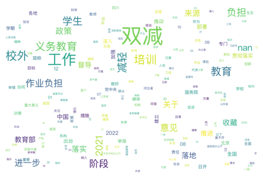

```python
# 根据词袋模型分析结果绘制词云图
from wordcloud import WordCloud
import matplotlib.pyplot as plt

wordcloud = WordCloud(
    font_path='/System/Library/Fonts/PingFang.ttc',  # 指定中文字体文件路径
    background_color='white',  # 设置背景颜色
    width=1200,
    height=800,
    max_words=200,  # 设置最大显示的词数
    max_font_size=100  # 设置字体最大值
).generate_from_frequencies(word_freq)

# 显示词云图
plt.imshow(wordcloud, interpolation='bilinear')
plt.axis('off')
plt.show()
```

# # 民间双减数据分析

```python
import pandas as pd
```

```python
#读取数据
text_ana=pd.read_csv('民间双减数据.csv')
#text_ana=text_ana.drop(['Unnamed: 0'],axis=1)#Unnamed:需要有空格
text_ana
```

|  | 标题 | 标题链接 | m-box-col | 头像 | weibo-text | time | m-ctrl-box | m-ctrl-box1 | m-ctrl-box2 | from | m-icon | 缩略图 |
| --- | --- | --- | --- | --- | --- | --- | --- | --- | --- | --- | --- | --- |
| 0 | 南京北京东路王波聊双减,双减盐_,付大双减肥中,更多 | javascript:void(0) | NaN | NaN | NaN | NaN | NaN | NaN | NaN | NaN | NaN | https://tvax3.sinaimg.cn/crop.0.0.862.862.180/... |
| 1 | 小土大橙子,#双减# | javascript:void(0),javascript:; | #双减#0讨论 0阅读 | https://tvax1.sinaimg.cn/crop.0.0.640.640.180/... | 该说不说，最该减的就是语文吧。答案又不确定，考那么难是要干啥，课本一滴水考试一片海，不明确就... | 2024/1/18 18:45 | 59 | 237 | 1573 | 来自 iPhone 12 | https://h5.sinaimg.cn/upload/108/1866/2022/11/... | https://wx3.sinaimg.cn/thumb180/0024cZx9ly8hgy... |
| 2 | 美杜莎麻麻 | javascript:void(0) | 2 | https://tvax4.sinaimg.cn/crop.0.0.1080.1080.18... | 现在小学写得少，还有个减负双减的原因。 不过感觉今年好像没减那样厉害了，这学期有作业有单元测... | 2024/1/4 11:29 | 2 | 92 | 88 | 来自 nova8 我由我掌镜 | https://h5.sinaimg.cn/upload/108/1866/2022/11/... | NaN |
| 3 | 晏凌羊 | javascript:void(0) | 3 | https://tva2.sinaimg.cn/crop.0.0.750.750.180/5... | 网友私信（后附胖羊回复）： 羊羊好，匿名公开咨询。 非常同意你写的”生活在这片土地上，不... | 2024/1/25 0:05 | 3 | 6 | 64 | 来自 微博网页版 | https://h5.sinaimg.cn/upload/108/1866/2022/11/... | NaN |
| 4 | 初见旧城以西,#长安区教育局# | javascript:void(0),javascript:; | #长安区教育局#0讨论 0阅读 | https://tvax1.sinaimg.cn/crop.0.0.1058.1058.18... | #长安区教育局##兴国中学##双减政策# 西安市长安区兴国中学提前开学，无视国家的寒假放假计... | 2024/2/19 16:28 | 18 | 16 | 83 | 来自 iPhone客户端 | NaN | https://wx2.sinaimg.cn/thumb180/0024cZx9ly8gyd... |
| ... | ... | ... | ... | ... | ... | ... | ... | ... | ... | ... | ... | ... |
| 4995 | 静海发布 | javascript:void(0) | 15 | https://tvax3.sinaimg.cn/crop.0.0.512.512.180/... | #静海新闻##魅力静海# 【假期有他们，很安心……】 为深入贯彻落实党中... | 2024/4/8 10:04 | 15 | 7 | 13 | 来自 微博网页版 | NaN | https://wx4.sinaimg.cn/orj360/bd9f55cfly1hoj73... |
| 4996 | 糖糖果糖正能量 | javascript:void(0) | 转发 | https://tvax1.sinaimg.cn/crop.0.0.512.512.180/... | #教授建议小学低年级免去考试和成绩#治标不治本，你光逮着低年级嚯嚯有啥用？中考50%的淘汰率... | 2024/4/8 9:46 | 转发 | 4 | 12 | 来自 iPhone 12 | https://h5.sinaimg.cn/upload/108/1866/2022/11/... | NaN |
| 4997 | 中国教育新闻网 | javascript:void(0) | 转发 | https://tvax2.sinaimg.cn/crop.3.10.188.188.180... | 【从最薄弱处入手】“太空丝瓜种子和普通的丝瓜种子一样吗？”近日，在山东省菏泽市牡丹区都司镇白... | 2024/4/8 9:34 | 转发 | 评论 | 赞 | 来自 微博网页版 | https://h5.sinaimg.cn/upload/108/1866/2022/11/... | NaN |
| 4998 | 蔓越小莓 | javascript:void(0) | 转发 | https://tvax1.sinaimg.cn/crop.0.0.512.512.180/... | 今天K3要去参观隔壁的小学咯！去看看你不会过的那种生活这个片区的公立可卷了，乐乐那批没赶上双... | 2024/4/8 8:17 | 转发 | 评论 | 赞 | 来自 iPhone 15 Pro Max | https://h5.sinaimg.cn/upload/108/1866/2022/11/... | https://wx2.sinaimg.cn/orj360/78417387gy1hoj3v... |
| 4999 | 陕西都市热线 | javascript:void(0) | 转发 | https://tvax1.sinaimg.cn/crop.0.0.512.512.180/... | 【西安市教育局通报违规校外培训行为】西安市碑林区、长安区、高陵区严格落实《校外培训行政处罚暂... | 2024/4/7 18:11 | 转发 | 评论 | 赞 | 来自 微博网页版 | https://h5.sinaimg.cn/upload/108/1866/2022/11/... | https://wx2.sinaimg.cn/orj360/6d146ea8ly1hoifk... |

5000 rows × 12 columns

# # # 数据预处理

```python
#分析语料
text=list(text_ana['weibo-text'])
text
```

```
[nan,
 '该说不说，最该减的就是语文吧。答案又不确定，考那么难是要干啥，课本一滴水考试一片海，不明确就是造成恐慌和疯狂内卷的因素之一 #双减#',
 '现在小学写得少，还有个减负双减的原因。 不过感觉今年好像没减那样厉害了，这学期有作业有单元测验有安排期末复习书面考试的学校，好像比之前多了一些。 评论区聊聊，从去年到今年学校作业考试等安排有变化么？',
 '网友私信（后附胖羊回复）：  羊羊好，匿名公开咨询。  非常同意你写的”生活在这片土地上，不要跟政策对着干“。那么，关于双减政策下的教育培训行业能存在多久，请教羊有什么见解？是否需要转行？  本人位于18线小城市，去年靠烧烤爆火。毕业后一直从事英语学科教培八九年了，学校也开了15年了。双减 ...全文',
 '#长安区教育局##兴国中学##双减政策# 西安市长安区兴国中学提前开学，无视国家的寒假放假计划将双减政策视为粪土，长安区教育局助纣为虐，伙同兴国中学无视放假计划与双减政策，举报电话主动挂断，无视举报内容，让人民自己消化问题，专制的蛮横与霸道显现在我们眼前，这难道就是国家机关吗？我们反映 ...全文',
 '苏新航你再这么黏我可就诅咒重庆中小学双减政策取消了啊！',
 '“双减“到底减了谁？北大教授的研究结果出乎意料，却触目惊心！#双减政策##内卷还是躺平##寒门再难出贵子##升学教育##升学压力# 乔爸在海淀的微博视频',
 nan,
 '双减政策虽然很美好，但现实很残酷. 拿只是校园足球的小学阶段，有实力的家长一节课500-1000都会高价找私教提高. 而面对“学习”这条能改变人生的路，哪怕没实力的家长也会倾尽所有去赶上那班车.很多家庭收入在1万的家庭基本愿意用六千去补各种课.因为你不高价上车，你确实就要徒步去罗马了  ...全文',
 '�对，这就是家长想说的！关于“双减政策”，我认为基层政府及其不作为！#满大街的无证照非法辅导机构#，他愣是没人管没人问！@微言教育 扎西德勒·天珠文化的微博视频',
 '#泉州教育局要求严禁给家长布置作业#【#泉州教育局要求严格落实双减#，严禁要求家长检查、批改作业】近日，泉州市教育局印发《关于进一步加强义务教育阶段学校作业管理工作的提示函》，强调三个“严禁”、三个“不得”和三个“杜绝”。三个“严禁”：严禁给家长布置或变相布置作业；严禁要求家长检查、 ...全文',
 '既要双减，又要以一分三率的标准考核教师 真的没劲透了，苦的都是没有后台没有权利的普通教师，导致教学生束手束脚。',
 '家楼下的商场，一层卖衣服的被改为教育机构，奇怪双减了都，还培训啥，一看“科学”、“演讲”、“思维”.....乌压压全是孩子，两百多三百一节课。  平常没人的汉堡王坐满了家长和孩子，所以儿童人口跟上，一系列的消费就全都跟上了，教辅培训餐饮娱乐旅游。  听见旁边有个妈妈跟五六岁女儿谈心 ...全文',
 '真的被这个学校笑死了  我们这个学校是当地算数一数二的学校了，成绩也非常不错  但是，学校的制度不咋地，每次不管是考试还是放小长假的时候，都要补回来，我真笑了，人家国家要求放的节假日你往回补什么啊，要补就憋放呀！还有，请问我国的双减政策到底是什么东西？就是让我们周六周日 ...全文',
 '我前面喷猫一杯我觉得太个人情绪了 编段子的网红那么多 恶心的无下限的更多，仅仅因为撞上了双减和打击网红政策的风口，就直接封杀，毫无规则可言 所有人都可以讨厌这个逼网红，因为她说一些无意义的脑瘫段子还用着甲亢一样的语气 但是没人可以剥夺她说话和创作的权利，国家也不行',
 '特斯拉“双减”，刚裁员又降价！ModelY最低仅29.99万元#特斯拉全球裁员10%#特斯拉#特斯拉降价# 驾驭纵横的微博视频',
 '私学校，我还以为这么大好心给我们放休两天，结果你和我说领导来检查我们双减政策实行的',
 '【河北保定高新区：书香满园 阅读蔚然成风】 为在推动双减政策落地的同时，让学生们养成良好的阅读习惯。近日，北京师范大学保定实验学校召开“助力‘双减’，全民阅读进校园”系列活动。 低年级学生在专任教师和家长的引导下，一起读绘本、走进汉字的天地，从遥远的甲骨文中探索汉字的前世今生、了解 ...全文',
 '#湖南失踪15岁男孩遗体已找到# 一定要将“双减”进行到底！！！！',
 '说到女网红编造捡到低年级小学生的寒假作业被全网封的理由是顶撞了双减政策，所以封了 我想起了去年的某男贫困生网红僧丫编造自己的贫困生救助金全部被学校侵吞，给富哥室友占了。当时连续上了三十多个热搜。一对媒体问责学校，一堆大v冲进该学校“问责”。甚至一些男大v爱国都不装了，阴阳怪气起国家 ...全文',
 '这可比抓双减得人心多了,@西部决策:\n      【#小学保留平房教室穿越感拉满#：让人秒回八零九零年代】近日，山东济南。济南一小学还保留平房教室，让人秒回八零九零年代。据学校老师表示，学校里有很多古植物保留了下来，还是以前八九十年代的风格。这里没有高楼大厦，有的只是鸟语花香，是一个让你梦回童年的地方。@西部决策  ...全文',
 '河南省教育厅双减减哪了？违规补课你们管不管',
 '朋友请欣赏聆听《银发助“双减”》 qqpuer的微博视频',
 '#央媒发文放假绝不是假放#真服了，双减双休哪个做到了没改变根本问题光在这发文',
 '被疫情、双减残害的一代 拼音不扎实 书写不工整 全班作文起码一半前后不衔接、逻辑有问题 大部分病句连天 教得太快 学得太急 最后一问  什么都不知道',
 '【#昆一中西山学校春风杯班级足球联赛火热开展# 】为切实促进“双减”政策下学生的体质健康，融合五育和谐发展，提升学生体育运动水平，丰富校园文化生活。昆一中西山学校已经连续数年在校内组织开展“春风杯”班级足球联赛，为全体师生精心打造了一场独具特色的校园体育赛事。4月12日下午5点，昆一中 ...全文',
 '现在是双减时代，从小学到中学，课业负担已经大幅降低，小学一二年级不允许布置书面作业，也没有考试。一些年轻夫妇们一看，孩子生活得不幸福啊，算了，不生了！生育率一下子又被拉下去一大截。另一些人看到出去旅个游还这么用功地带着作业，还骗我们说减负，我减了别人没减啊，那可不行，必须要卷起来,@升值计:\n      猫一杯其实最大的问题不是造谣，网红造谣，说谎的多了，就是猫一杯自己，也是谎话连篇，她撒的所有谎里，秦朗丢作业在巴黎算是最微不足道的一个。但是猫一杯为啥因为这个事被处理了，是不是因为以前撒谎太多，一起处理了，也不是。真正的问题是啥呢？ 升值计的微博视频',
 '两周放一天假，还要改卷子，双减到底是减给谁了啊！！',
 '双减政策减的什么？ 这是小学三年级的周末作业 现在过周末就像我的噩梦',
 '昨天地铁上看到一个人很像大学同学，还是我老乡，却得知她已经故去，双减裁员压力➕抑郁症➕爸妈不够关心，可见世事无常，能过好当下的生活已经很是不易了，女孩子不论如何还是要多爱自己一些，不管遇到什么事，都得开解自己。',
 '#我要求我女儿休学了一年#这个妈妈真的很开明，在现在双减政策下越来越卷的时刻真的好难得',
 '#晋中身边事# 【童真飞扬 运动无限】为进一步丰富校园文化生活，增进班级凝聚力，4月18日，榆次区中都路小学举办春季田径运动会。比赛中，孩子们努力拼搏，奋勇争先，展现了他们对体育运动的热情。据了解，本次运动会也是在“双减”政策下，对学校特色课程的一次检阅和汇报。（晋中日报）',
 '#通辽##开鲁# 开鲁融媒的微博视频',
 '昨天饭局上，聊到了“双减”这个话题。“双减”一是减轻作业总量和时长，二是减轻学生过重作业负担。  每个家长都希望孩子以后找个体面的工作，但能量是守恒的，这边减完后，那边家长鸡娃的压力会更大，培养成本更高。  几节课就大几百，普通家庭也吃不消，这样一来培训机构也不好做。  本质上换汤不换 ...全文',
 '箴言书苑  有孩子的家长，建议看看 T.T在教育孩子的过程中，学过很多理念，看过很多教育方法，但是面对自家孩子，有时候仍无可奈何……就像我们家的情况，由于双减，也没啥作业，造成了叫弟弟写作业，一回来就要玩会儿，可是他说的也有道理，“妈妈，我都在学校学1天了，我先放松玩会儿”我竟 ...全文',
 '风大\u3000可稍息否：怎么感觉双减之后越来越累了？  中国教育长期被冠以应试教育而责骂。那么应试教育是怎么回事呢？  应试教育的本质，是“教育资源供应缺乏与中国社会的教育需求旺盛之间的矛盾”。是中国的社会性质要求中国尽可能的为民众提供优质教育，而中国经济的不够发达又意味着各地教育资源的不平 ...全文',
 '一口气刷完6篇高中阅读之后只想骂人，从初中到高中仿佛坐了火箭，难度从0瞬间升到100，初中还在不停喊双减，到了高中立马就是各种科技文，生物文，咱就是说换成中文学生都不一定看得懂，更何况是英文，这个衔接明显就是有问题的啊，真的不是很理解如今的教育体系，双减到底要减什么，要减你倒是连高考 ...全文',
 '如果我是个正常人就好了。是个能正常去学校的人。是个在大街上正常交流的。是一个不会在意别人评论，只在乎自己的人。可是我做不到。做不到做不到。做不到。 做不到啊，我无论怎么努力都没用啊。我无论怎么告诉自己，一切都会好起来的也没用啊。 现实他就摆在那里啊。双减制度不允许补课就摆在那里。我 ...全文',
 '校外培训机构监管有寄 龙女 双减欲周全，法明无数篇。 经营虽为利，教化自生缘。 案牍绸缪处，尘风裹挟边。 不虞何所谓，坎险济疏先。',
 '自从双减后 小区的夜晚热闹非凡  小孩子没啥作业 吃完饭就在下面疯玩 完整的童年了',
```

[output cut: 946 more lines]

```
 '#教授建议小学低年级免去考试和成绩#治标不治本，你光逮着低年级嚯嚯有啥用？中考50%的淘汰率不改变，p用没有，家长该焦虑的还是焦虑，该补课的还是补课！你这双减无非是给老师减轻负担的最好理由，减的是老师，家长还是累亖，学生还是不快乐',
 '【从最薄弱处入手】“太空丝瓜种子和普通的丝瓜种子一样吗？”近日，在山东省菏泽市牡丹区都司镇白刘庄小学，牡丹区科协技术人员在流动科技馆为这里的小学生讲解太空种子和普通种子的区别，激发学生对科学的浓厚兴趣。  近年来，菏泽市牡丹区不断强化顶层设计，区域整体推进，在“双减”背景下做好科学 ...全文',
 '今天K3要去参观隔壁的小学咯！去看看你不会过的那种生活这个片区的公立可卷了，乐乐那批没赶上双减，幼儿园同学从一年级开始每周考试，每天两套卷子写到十一点，自己默写课文自己背单词，除了个人卷还特别强调集体荣誉，一个人不带红领巾全班没有流动红旗。只有一次在电梯里听个初三女生说他们 ...全文',
 '【西安市教育局通报违规校外培训行为】西安市碑林区、长安区、高陵区严格落实《校外培训行政处罚暂行办法》，密集开展多部门联合行动，不断加大执法力度，严厉打击校外培训机构违法违规行为。  西安市“双减”工作领导小组办公室4月7日发布关于3起违规校外培训行为处罚情况的通报，对刘某、王某某、林 ...全文',
 '学校抉择方向塔罗预测：现在的家长越来越重视孩子的教育，从上幼儿园之前就想把最好的都给孩子。每到孩子要上幼儿园的时候，总能听到家长们讨论关于公立幼儿园还是私立幼儿园好，尤其是双减政策发布后，家长们更是不知道该怎么选了。提早预测各类事件，破解不利因素',
 '实时播报：【西安发布3起违规校外培训行为处罚情况通报】据西安市教育局官方微信公众号消息，西安市“双减”工作领导小组办公室7日发布3起违规校外培训行为处罚情况通报。西安市碑林区、长安区、高陵区严格落实《校外培训行政处罚暂行办法》，密集开展多部门联合行动，不断加大执法力度，严厉打击校外 ...全文',
 '#世上神马研究都有# 一篇论文，关于“双减”后，一个城市中等生家庭的选择。  �关阳,程猛.心口不一:“双减”背景下一个城市中等生家庭的教育选择[J].天津师范大学学报(社会科学版),2024(01):115-124.  �中等生一般指在班级学业成绩处于中游的学生。在普职分流的背景下，本文的中等生指的是成绩处 ...全文',
 '#热点帮视频# 速扩！泉州市教育局发布严格落实“双减”via@第一帮帮团 第一帮帮团的微博视频',
 '#静海新闻##魅力静海# 【假期有他们，很安心……】           为深入贯彻落实党中央、国务院关于加强未成年人保护工作的决策部署，有效助力“双减”工作落地落实，引导和帮助学生度过安全、快乐、有意义的假期，静海义工队成立“护航假期”小队，积极组织适合未成年人的公益活动，为孩子们办好“家门口 ...全文',
 '#教授建议小学低年级免去考试和成绩#治标不治本，你光逮着低年级嚯嚯有啥用？中考50%的淘汰率不改变，p用没有，家长该焦虑的还是焦虑，该补课的还是补课！你这双减无非是给老师减轻负担的最好理由，减的是老师，家长还是累亖，学生还是不快乐',
 '【从最薄弱处入手】“太空丝瓜种子和普通的丝瓜种子一样吗？”近日，在山东省菏泽市牡丹区都司镇白刘庄小学，牡丹区科协技术人员在流动科技馆为这里的小学生讲解太空种子和普通种子的区别，激发学生对科学的浓厚兴趣。  近年来，菏泽市牡丹区不断强化顶层设计，区域整体推进，在“双减”背景下做好科学 ...全文',
 '今天K3要去参观隔壁的小学咯！去看看你不会过的那种生活这个片区的公立可卷了，乐乐那批没赶上双减，幼儿园同学从一年级开始每周考试，每天两套卷子写到十一点，自己默写课文自己背单词，除了个人卷还特别强调集体荣誉，一个人不带红领巾全班没有流动红旗。只有一次在电梯里听个初三女生说他们 ...全文',
 '【西安市教育局通报违规校外培训行为】西安市碑林区、长安区、高陵区严格落实《校外培训行政处罚暂行办法》，密集开展多部门联合行动，不断加大执法力度，严厉打击校外培训机构违法违规行为。  西安市“双减”工作领导小组办公室4月7日发布关于3起违规校外培训行为处罚情况的通报，对刘某、王某某、林 ...全文',
 '学校抉择方向塔罗预测：现在的家长越来越重视孩子的教育，从上幼儿园之前就想把最好的都给孩子。每到孩子要上幼儿园的时候，总能听到家长们讨论关于公立幼儿园还是私立幼儿园好，尤其是双减政策发布后，家长们更是不知道该怎么选了。提早预测各类事件，破解不利因素',
 ...]
```

```python
import jieba
def word_segmentation(text):
    words=jieba.lcut(text)
    return ' '.join(words)
text_ana['weibo-text']=text_ana['weibo-text'].iloc[:100]\
.astype(str).apply(word_segmentation)
text_ana['weibo-text'].head()
```

```
0                                                  nan
1    该 说 不 说 ， 最 该减 的 就是 语文 吧 。 答案 又 不 确定 ， 考 那么 难是...
2    现在 小学 写得少 ， 还有 个 减负 双减 的 原因 。   不过 感觉 今年 好像 没减...
3    网友 私信 （ 后 附胖羊 回复 ） ：     羊羊 好 ， 匿名 公开 咨询 。    ...
4    # 长安区 教育局 ## 兴国 中学 ## 双减 政策 #   西安市 长安区 兴国 中学 ...
Name: weibo-text, dtype: object
```

```python
text=list(text_ana['weibo-text'].dropna())
text
```

```
['nan',
 '该 说 不 说 ， 最 该减 的 就是 语文 吧 。 答案 又 不 确定 ， 考 那么 难是 要 干 啥 ， 课本 一滴水 考试 一片 海 ， 不 明确 就是 造成 恐慌 和 疯狂 内卷 的 因素 之一   # 双减 #',
 '现在 小学 写得少 ， 还有 个 减负 双减 的 原因 。   不过 感觉 今年 好像 没减 那样 厉害 了 ， 这 学期 有 作业 有 单元 测验 有 安排 期末 复习 书面 考试 的 学校 ， 好像 比 之前 多 了 一些 。   评论 区 聊聊 ， 从 去年 到 今年 学校 作业 考试 等 安排 有 变化 么 ？',
 '网友 私信 （ 后 附胖羊 回复 ） ：     羊羊 好 ， 匿名 公开 咨询 。     非常 同意 你 写 的 ” 生活 在 这片 土地 上 ， 不要 跟 政策 对着干 “ 。 那么 ， 关于 双减 政策 下 的 教育 培训 行业 能 存在 多久 ， 请教 羊有 什么 见解 ？ 是否 需要 转行 ？     本人 位于 18 线 小 城市 ， 去年 靠 烧烤 爆火 。 毕业 后 一直 从事 英语 学科 教培 八九年 了 ， 学校 也 开 了 15 年 了 。 双减   ... 全文',
 '# 长安区 教育局 ## 兴国 中学 ## 双减 政策 #   西安市 长安区 兴国 中学 提前 开学 ， 无视 国家 的 寒假 放假 计划 将 双减 政策 视为 粪土 ， 长安区 教育局 助纣为虐 ， 伙同 兴国 中学 无视 放假 计划 与 双减 政策 ， 举报电话 主动 挂断 ， 无视 举报 内容 ， 让 人民 自己 消化 问题 ， 专制 的 蛮横 与 霸道 显现 在 我们 眼前 ， 这 难道 就是 国家机关 吗 ？ 我们 反映   ... 全文',
 '苏 新航 你 再 这么 黏 我 可 就 诅咒 重庆 中小学 双减 政策 取消 了 啊 ！',
 '“ 双减 “ 到底 减 了 谁 ？ 北大 教授 的 研究 结果 出乎意料 ， 却 触目惊心 ！ # 双减 政策 ## 内卷 还是 躺平 ## 寒门 再 难出 贵子 ## 升学 教育 ## 升学压力 #   乔爸 在 海淀 的 微博 视频',
 'nan',
 '双减 政策 虽然 很 美好 ， 但 现实 很 残酷 .   拿 只是 校园 足球 的 小学 阶段 ， 有 实力 的 家长 一节课 500 - 1000 都 会 高价 找 私教 提高 .   而 面对 “ 学习 ” 这条 能 改变 人生 的 路 ， 哪怕 没 实力 的 家长 也 会 倾尽 所有 去 赶上 那 班车 . 很多 家庭收入 在 1 万 的 家庭 基本 愿意 用 六千 去 补 各种 课 . 因为 你 不 高价 上车 ， 你 确实 就要 徒步 去 罗马 了     ... 全文',
 '� 对 ， 这 就是 家长 想 说 的 ！ 关于 “ 双减 政策 ” ， 我 认为 基层 政府 及其 不 作为 ！ # 满大街 的 无证照 非法 辅导 机构 # ， 他 愣 是 没人管 没人 问 ！ @ 微言 教育   扎西德勒 · 天珠 文化 的 微博 视频',
 '# 泉州 教育局 要求 严禁 给 家长 布置 作业 # 【 # 泉州 教育局 要求 严格 落实 双减 # ， 严禁 要求 家长 检查 、 批改作业 】 近日 ， 泉州市 教育局 印发 《 关于 进一步 加强 义务教育 阶段 学校 作业管理 工作 的 提示 函 》 ， 强调 三个 “ 严禁 ” 、 三个 “ 不得 ” 和 三个 “ 杜绝 ” 。 三个 “ 严禁 ” ： 严禁 给 家长 布置 或 变相 布置 作业 ； 严禁 要求 家长 检查 、   ... 全文',
 '既要 双减 ， 又 要 以 一分 三率 的 标准 考核 教师   真的 没劲 透 了 ， 苦 的 都 是 没有 后台 没有 权利 的 普通 教师 ， 导致 教 学生 束手束脚 。',
 '家 楼下 的 商场 ， 一层 卖 衣服 的 被 改为 教育 机构 ， 奇怪 双减 了 都 ， 还 培训 啥 ， 一看 “ 科学 ” 、 “ 演讲 ” 、 “ 思维 ” ..... 乌 压压 全是 孩子 ， 两百多 三百 一节课 。     平常 没人 的 汉堡 王 坐满 了 家长 和 孩子 ， 所以 儿童 人口 跟上 ， 一系列 的 消费 就 全都 跟上 了 ， 教辅 培训 餐饮 娱乐 旅游 。     听见 旁边 有个 妈妈 跟 五六岁 女儿 谈心   ... 全文',
 '真的 被 这个 学校 笑 死 了     我们 这个 学校 是 当地 算 数一数二 的 学校 了 ， 成绩 也 非常 不错     但是 ， 学校 的 制度 不 咋 地 ， 每次 不管 是 考试 还是 放小 长假 的 时候 ， 都 要 补 回来 ， 我 真 笑 了 ， 人家 国家 要求 放 的 节假日 你 往回 补 什么 啊 ， 要 补 就 憋 放 呀 ！ 还有 ， 请问 我国 的 双减 政策 到底 是 什么 东西 ？ 就是 让 我们 周六 周日   ... 全文',
 '我 前面 喷猫 一杯 我 觉得 太 个人 情绪 了   编 段子 的 网红 那么 多   恶心 的 无 下限 的 更 多 ， 仅仅 因为 撞 上 了 双减 和 打击 网红 政策 的 风口 ， 就 直接 封杀 ， 毫无 规则 可言   所有人 都 可以 讨厌 这个 逼 网红 ， 因为 她 说 一些 无 意义 的 脑瘫 段子 还用 着 甲亢 一样 的 语气   但是 没 人 可以 剥夺 她 说话 和 创作 的 权利 ， 国家 也 不行',
 '特斯拉 “ 双减 ” ， 刚 裁员 又 降价 ！ ModelY 最低 仅 29.99 万元 # 特斯拉 全球 裁员 10% # 特斯拉 # 特斯拉 降价 #   驾驭 纵横 的 微博 视频',
 '私 学校 ， 我 还 以为 这么 大 好心 给 我们 放休 两天 ， 结果 你 和 我 说 领导 来 检查 我们 双减 政策 实行 的',
 '【 河北 保定 高新区 ： 书香 满园   阅读 蔚然成风 】   为 在 推动 双减 政策 落地 的 同时 ， 让 学生 们 养成 良好 的 阅读 习惯 。 近日 ， 北京师范大学 保定 实验学校 召开 “ 助力 ‘ 双减 ’ ， 全民 阅读 进校园 ” 系列 活动 。   低年级 学生 在 专任教师 和 家长 的 引导 下 ， 一起 读绘本 、 走进 汉字 的 天地 ， 从 遥远 的 甲骨文 中 探索 汉字 的 前世 今生 、 了解   ... 全文',
 '# 湖南 失踪 15 岁 男孩 遗体 已 找到 #   一定 要 将 “ 双减 ” 进行 到底 ！ ！ ！ ！',
 '说 到 女网 红 编造 捡 到 低年级 小学生 的 寒假作业 被 全网 封 的 理由 是 顶撞 了 双减 政策 ， 所以 封 了   我 想起 了 去年 的 某 男 贫困生 网红僧 丫 编造 自己 的 贫困生 救助金 全部 被 学校 侵吞 ， 给 富哥 室友 占 了 。 当时 连续 上 了 三十多个 热 搜 。 一对 媒体 问责 学校 ， 一堆 大 v 冲进 该 学校 “ 问责 ” 。 甚至 一些 男大 v 爱国 都 不装 了 ， 阴阳怪气 起 国家   ... 全文',
 '这 可比 抓 双减 得人心 多 了 , @ 西部 决策 : \n             【 # 小学 保留 平房 教室 穿越 感拉满 # ： 让 人 秒 回八零 九零 年代 】 近日 ， 山东 济南 。 济南 一 小学 还 保留 平房 教室 ， 让 人 秒 回八零 九零 年代 。 据 学校 老师 表示 ， 学校 里 有 很多 古 植物 保留 了 下来 ， 还是 以前 八 九十年代 的 风格 。 这里 没有 高楼大厦 ， 有 的 只是 鸟语花香 ， 是 一个 让 你 梦回 童年 的 地方 。 @ 西部 决策     ... 全文',
 '河南省 教育厅 双减 减 哪 了 ？ 违规 补课 你们 管 不管',
 '朋友 请 欣赏 聆听 《 银发 助 “ 双减 ” 》   qqpuer 的 微博 视频',
 '# 央媒 发文 放假 绝不 是 假放 # 真服了 ， 双减 双休 哪个 做到 了 没 改变 根本 问题 光 在 这 发文',
 '被 疫情 、 双减 残害 的 一代   拼音 不 扎实   书写 不 工整   全班 作文 起码 一半 前后 不 衔接 、 逻辑 有 问题   大部分 病句 连天   教得 太快   学得 太急   最后 一问     什么 都 不 知道',
 '【 # 昆 一中 西山 学校 春风 杯 班级 足球联赛 火热 开展 #   】 为 切实 促进 “ 双减 ” 政策 下 学生 的 体质 健康 ， 融合 五育 和谐 发展 ， 提升 学生 体育运动 水平 ， 丰富 校园文化 生活 。 昆 一中 西山 学校 已经 连续 数年 在 校内 组织 开展 “ 春风 杯 ” 班级 足球联赛 ， 为 全体师生 精心 打造 了 一场 独具特色 的 校园 体育赛事 。 4 月 12 日 下午 5 点 ， 昆 一中   ... 全文',
```

[output cut: 74 more lines]

# # # 构建词袋模型

```python
from sklearn.feature_extraction.text import CountVectorizer
#初始化CounVectorizer
vectorizer=CountVectorizer()
#将文本数据转换为词袋特征矩阵
X=vectorizer.fit_transform(text)
#展示特征矩阵的形状
print('词袋特征矩阵的形状:',X.shape)
#展示词袋模型中的所有特征词
print('特征词列表:',vectorizer.get_feature_names_out())
```

```
词袋特征矩阵的形状: (100, 1714)
特征词列表: ['10' '100' '1000' ... '鼓励' '鼓楼' '鼓楼区']
```

```python
list(X)
```

[output not shown]

[output cut: 145 more lines]

```
 	with 6 stored elements in Compressed Sparse Row format>,
 <1x1714 sparse matrix of type '<class 'numpy.int64'>'
 	with 42 stored elements in Compressed Sparse Row format>,
 <1x1714 sparse matrix of type '<class 'numpy.int64'>'
 	with 14 stored elements in Compressed Sparse Row format>,
 <1x1714 sparse matrix of type '<class 'numpy.int64'>'
 	with 26 stored elements in Compressed Sparse Row format>,
 <1x1714 sparse matrix of type '<class 'numpy.int64'>'
 	with 32 stored elements in Compressed Sparse Row format>,
 <1x1714 sparse matrix of type '<class 'numpy.int64'>'
 	with 7 stored elements in Compressed Sparse Row format>,
 <1x1714 sparse matrix of type '<class 'numpy.int64'>'
 	with 33 stored elements in Compressed Sparse Row format>,
 <1x1714 sparse matrix of type '<class 'numpy.int64'>'
 	with 4 stored elements in Compressed Sparse Row format>]
```

```python
#词袋矩阵，每一行每个词出现几次
list(X.toarray())
```

[output not shown]

[output cut: 45 more lines]

```
 array([0, 0, 0, ..., 0, 0, 0]),
 array([0, 0, 0, ..., 0, 0, 0]),
 array([0, 0, 0, ..., 0, 0, 0]),
 array([0, 0, 0, ..., 0, 0, 0]),
 array([0, 0, 0, ..., 0, 0, 0]),
 array([0, 0, 0, ..., 0, 0, 0]),
 array([0, 0, 0, ..., 0, 0, 0]),
 array([0, 0, 0, ..., 0, 0, 0]),
 array([0, 0, 0, ..., 0, 0, 0]),
 array([0, 0, 0, ..., 0, 0, 0]),
 array([0, 0, 0, ..., 0, 0, 0]),
 array([0, 0, 0, ..., 0, 0, 0]),
 array([0, 0, 0, ..., 0, 0, 0]),
 array([0, 0, 0, ..., 0, 0, 0]),
 array([0, 0, 0, ..., 0, 0, 0])]
```

# # # 词频统计

```python
#获取词汇表
feature_words=vectorizer.get_feature_names_out()
#计算词频
word_freq=dict(zip(feature_words,X.sum(axis=0).A1))
```

```python
# 词袋模型中不重复的词汇的数量
len(word_freq)
```

```
1714
```

```python
sorted(word_freq.items(),key=lambda X: X[1],reverse=True)
```

```
[('双减', 109),
 ('全文', 38),
 ('政策', 36),
 ('教育', 35),
 ('培训', 31),
 ('学校', 31),
 ('学生', 28),
 ('小学', 21),
 ('活动', 20),
 ('作业', 18),
 ('我们', 17),
 ('家长', 16),
 ('机构', 16),
 ('工作', 14),
 ('什么', 13),
 ('校外', 13),
 ('落实', 13),
 ('哈哈哈', 12),
 ('就是', 12),
 ('还是', 12),
 ('孩子', 11),
 ('开展', 11),
 ('微博', 11),
 ('视频', 11),
 ('这个', 11),
 ('一个', 10),
 ('到底', 10),
 ('学科', 10),
 ('现在', 10),
 ('生活', 10),
 ('真的', 10),
 ('自己', 10),
 ('要求', 10),
 ('违规', 10),
 ('提升', 9),
 ('监管', 9),
 ('因为', 8),
 ('很多', 8),
 ('教育局', 8),
 ('近日', 8),
```

[output cut: 946 more lines]

```
 ('安徽省教育厅', 1),
 ('安逸', 1),
 ('安防', 1),
 ('完全', 1),
 ('完整', 1),
 ('官方版', 1),
 ('实事', 1),
 ('实效性', 1),
 ('实现', 1),
 ('实行', 1),
 ('实验区', 1),
 ('审核', 1),
 ('宣传', 1),
 ('室友', 1),
 ...]
```

# # # 词云图

```python
import matplotlib.pyplot as plt
from matplotlib import font_manager

for font in font_manager.fontManager.ttflist:
    # 查看字体名以及对应的字体文件名
    print(font.name, '-', font.fname)
```

[output not shown]

[output cut: 340 more lines]

[output not shown]

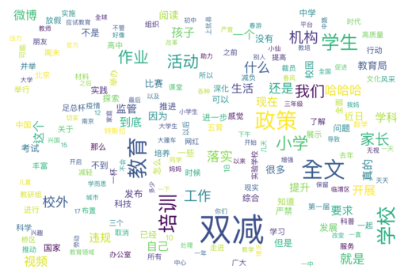

```python
# 根据词袋模型分析结果绘制词云图
from wordcloud import WordCloud
import matplotlib.pyplot as plt

wordcloud = WordCloud(
    font_path='/System/Library/Fonts/PingFang.ttc',  # 指定中文字体文件路径
    background_color='white',  # 设置背景颜色
    width=1200,
    height=800,
    max_words=200,  # 设置最大显示的词数
    max_font_size=100  # 设置字体最大值
).generate_from_frequencies(word_freq)

# 显示词云图
plt.imshow(wordcloud, interpolation='bilinear')
plt.axis('off')
plt.show()
```